# Bayesian inference with JAGS

[JAGS](https://en.wikipedia.org/wiki/Just_another_Gibbs_sampler) stands for “Just Another Gibbs Sampler” and is a tool for analysis of Bayesian hierarchical models using Markov Chain Monte Carlo (MCMC) simulation. It is an engine - more precisely, it is a *probabilistic programming language* ([PPL](https://en.wikipedia.org/wiki/Probabilistic_programming)) - for running BUGS in Unix-based environments and allows users to write their own functions, distributions and samplers.

In contrast to its ancestor, BUGS, JAGS has no graphical user interface (GUI). Thus, it must be run in a separate program, such as R. The following requirements are needed for using JAGS in R:

1. Download and install R and R Studio;
2. Download and install the latest version of [JAGS](https://sourceforge.net/projects/mcmc-jags/files/) depending on your operating system.
3. Install the `rjags` and `coda` packages in `R`.

In the remainder, several models for which Gibbs sampling with `JAGS` can be used are introduced as examples.

# Example 1: *Warm up*

Do people prefer using the word “data” in the singular or plural?

Data journalists at *FiveThirtyEight* conducted a [poll](https://fivethirtyeight.com/features/elitist-superfluous-or-popular-we-polled-americans-on-the-oxford-comma/) to address, among others, this question.

In particular, they asked the respondents which of the following sentence they prefer:

1. Some experts say it’s important to drink milk, but the data is inconclusive.
2. Some experts say it’s important to drink milk, but the data are inconclusive.

It turned out that 31 persons out of 35 prefer using data in the singular.

We want to specify a proper model for doing inference on the probability $p$ that $y$ out of $n$ persons prefer one expression or the other.

```r
# Clear the workspace:
rm(list=ls())

# Set the seed:
set.seed(1)

# Set the data:
n = 35
y = 31

# Create the list object:
dataList = list(y = y, n = n)

# Load the packages:
library(rjags)
library(coda)
```

Thus, we consider the Beta-Binomial model,

$$\begin{align*}
y\mid p & \sim Bin(n,p) \\
p & \sim Be(\alpha, \beta)
\end{align*}$$

that was introduced in the first lab, where $\alpha=3$ and $\beta=1$. Then,

1. write this model using the BUGS syntax and wrap it in the `textConnection()` function;
2. fit the model using `jags.model`, draw the burn-in samples and check for convergence using `update`, and finally draw samples from the full conditional posterior with `coda.samples`;
3. display diagnostics and trace plots;
4. compute and display the posterior predictive density of $y_{new}\mid y$.

JAGS allows the user either to store the model specification as a separate file using a text editor or to embed the BUGS model into R. The syntax is very simple and intuitive, see the [user guide](https://people.stat.sc.edu/hansont/stat740/jags_user_manual.pdf) for any help. For the purpose of learning JAGS we will always opt for the inline specification, below called `model_string`. Finally, we need to call the dependent variable, covariates, number of observations and number of covariates as declared the code, in our example being respectively `y` and `n`, and store them in a list `dataList`.

1. Implement the model in JAGS

```r
# Implement the JAGS code for this model
model_string = textConnection("model{

  # Likelihood
  y ~ dbin(p, n)

  # Prior: Beta(alpha, beta) with alpha = 3, beta = 1
  p ~ dbeta(3, 1)

  # Posterior predictive: a new observation given the same p
  y_new ~ dbin(p, n)

}")
```

2. Fit the model

```r
# MCMC settings
burn     = 5000
n.iter   = 10000
n.adapt  = 1000
thin     = 1
n.chains = 4   # multiple chains help diagnose convergence

# Compile the model
model = jags.model(model_string,
                   data    = dataList,
                   n.chains = n.chains,
                   n.adapt  = n.adapt)
```

```r
# Burn-in iterations (the chain converges to its stationary distribution)
update(model, n.iter = burn)

# Draw samples from the (full conditional) posterior, monitoring p and y_new
samples = coda.samples(model,
                       variable.names = c("p", "y_new"),
                       n.iter = n.iter,
                       thin   = thin)
```

3. Traceplots and diagnostics

```r
# Numerical summary of the posterior
print("Numerical summary of the posterior")
```

```
## [1] "Numerical summary of the posterior"
```

```r
summary(samples)
```

```
##
## Iterations = 6001:16000
## Thinning interval = 1
## Number of chains = 4
## Sample size per chain = 10000
##
## 1. Empirical mean and standard deviation for each variable,
##    plus standard error of the mean:
##
##          Mean      SD  Naive SE Time-series SE
## p      0.8717 0.05316 0.0002658      0.0003719
## y_new 30.5175 2.69052 0.0134526      0.0163364
##
## 2. Quantiles for each variable:
##
##          2.5%     25%     50%     75%   97.5%
## p      0.7507  0.8397  0.8783  0.9107  0.9557
## y_new 24.0000 29.0000 31.0000 33.0000 35.0000
```

```r
# Effective sample size: how many "independent" draws we effectively have
print("Effective sample size")
```

```
## [1] "Effective sample size"
```

```r
effectiveSize(samples)
```

```
##        p    y_new
## 20489.54 27158.32
```

```r
# Gelman-Rubin diagnostic: values close to 1 indicate convergence across chains
print("Gelman-Rubin diagnostic")
```

```
## [1] "Gelman-Rubin diagnostic"
```

```r
gelman.diag(samples)
```

```
## Potential scale reduction factors:
##
##       Point est. Upper C.I.
## p              1          1
## y_new          1          1
##
## Multivariate psrf
##
## 1
```

```r
# Trace plot + posterior density for p and y_new
print("Traceplots")
```

```
## [1] "Traceplots"
```

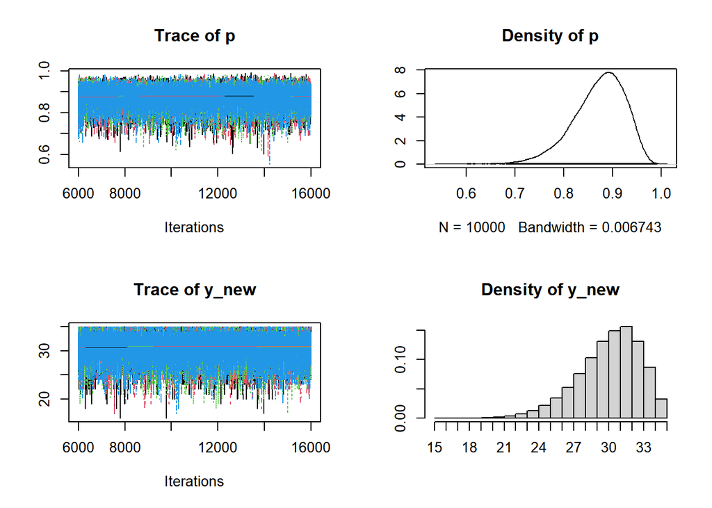

```r
plot(samples)
```

```r
# Autocorrelation plot (the Beta-Binomial is conjugate, so mixing should be excellent)
print("Autocorr")
```

```
## [1] "Autocorr"
```

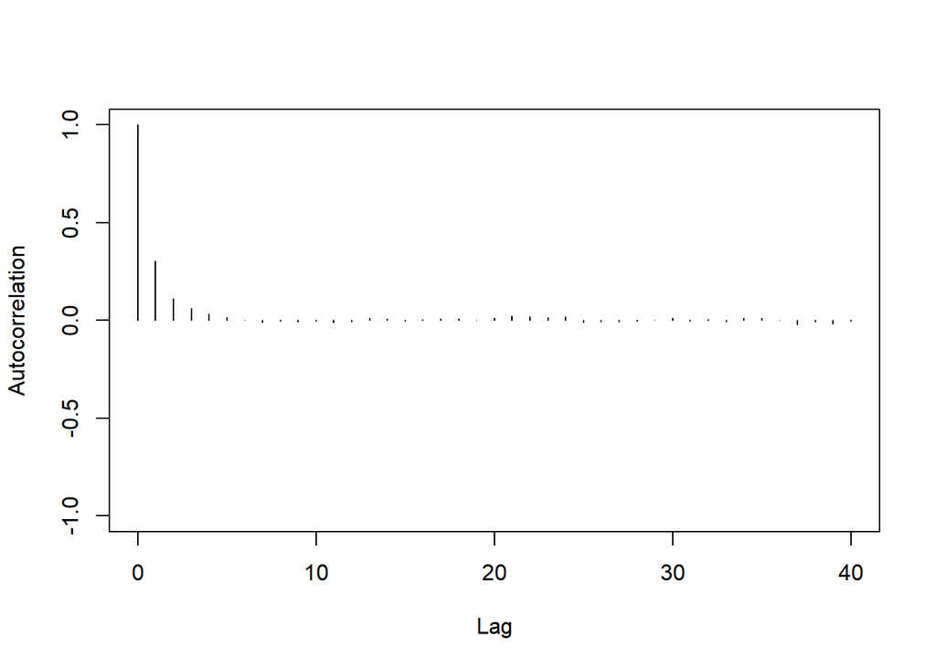

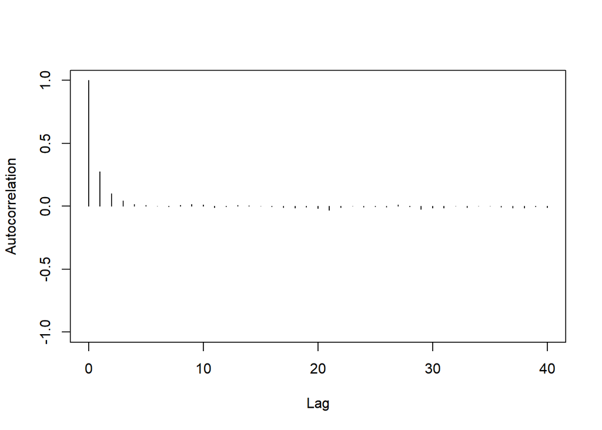

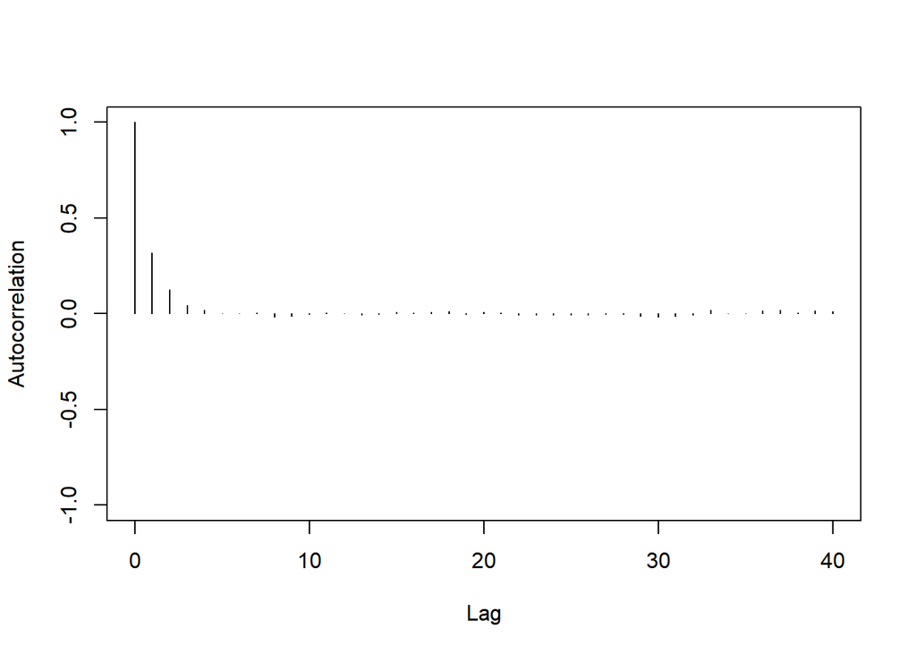

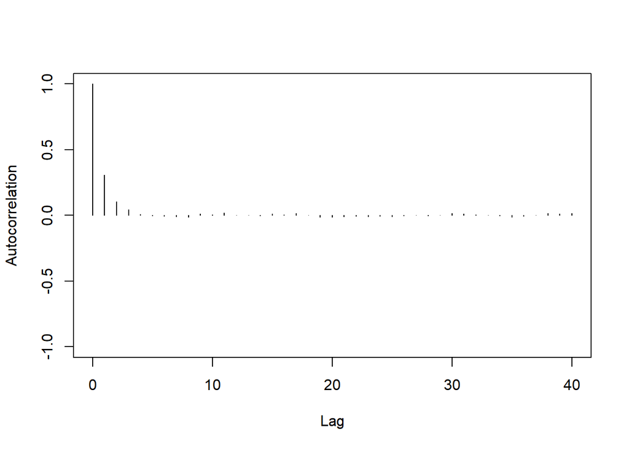

```r
autocorr.plot(samples[, "p"])
```

4. Posterior predictive density of y_new | y

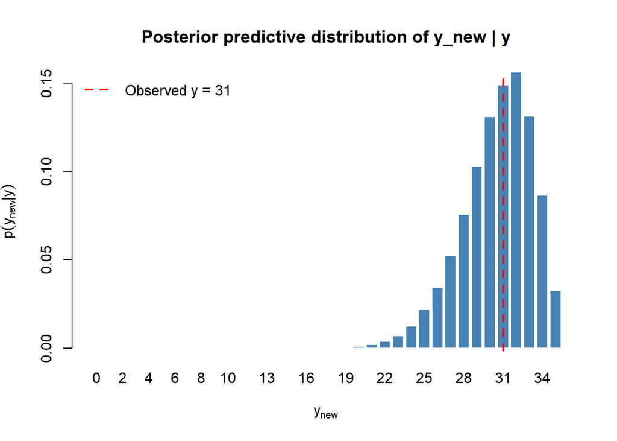

```r
# Pool the y_new samples from all chains
ynew_draws = as.numeric(unlist(samples[, "y_new"]))

# Empirical posterior predictive probabilities for y_new = 0, 1, ..., n
ynew_table = table(factor(ynew_draws, levels = 0:n))
ynew_probs = as.numeric(ynew_table) / sum(ynew_table)

# Plot the posterior predictive p.m.f.
bp = barplot(ynew_probs,
             names.arg = 0:n,
             col       = "steelblue",
             border    = "white",
             xlab      = expression(y[new]),
             ylab      = expression(p(y[new] * "|" * y)),
             main      = "Posterior predictive distribution of y_new | y")
# Highlight the observed value y on the predictive distribution
abline(v = bp[which(0:n == y)], col = "red", lwd = 2, lty = 2)
legend("topleft",
       legend = paste0("Observed y = ", y),
       col    = "red", lty = 2, lwd = 2, bty = "n")
```

```r
# A 95% posterior predictive credible interval for y_new
quantile(ynew_draws, probs = c(0.025, 0.5, 0.975))
```

```
##  2.5%   50% 97.5%
##    24    31    35
```

# Example 2: *Linear regression with the horseshoe prior*

Consider the dataset `BostonHousing2` about housing in Boston, available through the `mlbench` library, see the [link](https://www.rdocumentation.org/packages/mlbench/versions/2.1-3.1/topics/BostonHousing).

The original data are 506 observations on 14 variables, `medv` being the target variable:

- crim: per capita crime rate by town;
- zn: proportion of residential land zoned for lots over 25,000 sq.ft;
- indus: proportion of non-retail business acres per town;
- chas: Charles River dummy variable (= 1 if tract bounds river; 0 otherwise);
- nox: nitric oxides concentration (parts per 10 million);
- rm: average number of rooms per dwelling;
- age: proportion of owner-occupied units built prior to 1940;
- dis: weighted distances to five Boston employment centres;
- rad: index of accessibility to radial highways;
- tax: full-value property-tax rate per USD 10,000
- ptratio: pupil-teacher ratio by town;
- b: $1000(B-0.63)^{2}$ where $B$ is the proportion of blacks by town;
- lstat: percentage of lower status of the population;
- medv: median value of owner-occupied homes in USD 1000’s;

The corrected data set has the following additional columns:

- cmedv: corrected median value of owner-occupied homes in USD 1000’s;
- town: name of town;
- tract: census tract;
- lon: longitude of census tract;
- lat: latitude of census tract.

In this example we consider a linear regression model where `cmedv` is taken as the dependent variable. Similarly, we may consider `crim` as the variable of interest.

```r
rm(list=ls())

library(rjags)
library(coda)

# Import the dataset:
library(mlbench)
data(BostonHousing2)

# Clean the data:
bhousing = within(BostonHousing2,rm("medv","tract","town"))
bhousing$chas = as.numeric(bhousing$chas)

# Get the summary statistics:
summary(bhousing)
```

```
##       lon              lat            cmedv            crim
##  Min.   :-71.29   Min.   :42.03   Min.   : 5.00   Min.   : 0.00632
##  1st Qu.:-71.09   1st Qu.:42.18   1st Qu.:17.02   1st Qu.: 0.08205
##  Median :-71.05   Median :42.22   Median :21.20   Median : 0.25651
##  Mean   :-71.06   Mean   :42.22   Mean   :22.53   Mean   : 3.61352
##  3rd Qu.:-71.02   3rd Qu.:42.25   3rd Qu.:25.00   3rd Qu.: 3.67708
##  Max.   :-70.81   Max.   :42.38   Max.   :50.00   Max.   :88.97620
##        zn             indus            chas            nox
##  Min.   :  0.00   Min.   : 0.46   Min.   :1.000   Min.   :0.3850
##  1st Qu.:  0.00   1st Qu.: 5.19   1st Qu.:1.000   1st Qu.:0.4490
##  Median :  0.00   Median : 9.69   Median :1.000   Median :0.5380
##  Mean   : 11.36   Mean   :11.14   Mean   :1.069   Mean   :0.5547
##  3rd Qu.: 12.50   3rd Qu.:18.10   3rd Qu.:1.000   3rd Qu.:0.6240
##  Max.   :100.00   Max.   :27.74   Max.   :2.000   Max.   :0.8710
##        rm             age              dis              rad
##  Min.   :3.561   Min.   :  2.90   Min.   : 1.130   Min.   : 1.000
##  1st Qu.:5.886   1st Qu.: 45.02   1st Qu.: 2.100   1st Qu.: 4.000
##  Median :6.208   Median : 77.50   Median : 3.207   Median : 5.000
##  Mean   :6.285   Mean   : 68.57   Mean   : 3.795   Mean   : 9.549
##  3rd Qu.:6.623   3rd Qu.: 94.08   3rd Qu.: 5.188   3rd Qu.:24.000
##  Max.   :8.780   Max.   :100.00   Max.   :12.127   Max.   :24.000
##       tax           ptratio            b              lstat
##  Min.   :187.0   Min.   :12.60   Min.   :  0.32   Min.   : 1.73
##  1st Qu.:279.0   1st Qu.:17.40   1st Qu.:375.38   1st Qu.: 6.95
##  Median :330.0   Median :19.05   Median :391.44   Median :11.36
##  Mean   :408.2   Mean   :18.46   Mean   :356.67   Mean   :12.65
##  3rd Qu.:666.0   3rd Qu.:20.20   3rd Qu.:396.23   3rd Qu.:16.95
##  Max.   :711.0   Max.   :22.00   Max.   :396.90   Max.   :37.97
```

We visualize the variables’ distribution using the boxplot and analyze the linear relationships among the variables with a correlation matrix.

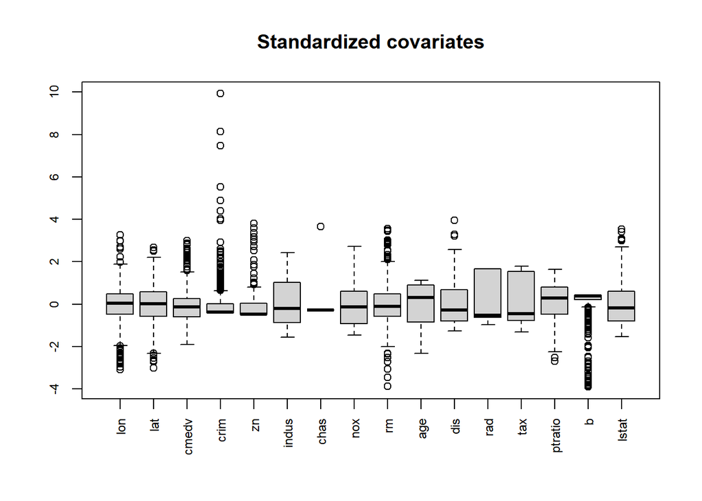

```r
# Boxplots:
par(mfrow=c(1, 1),pty="m")
boxplot(scale(bhousing),las=3,main="Standardized covariates",cex.axis=0.75)
```

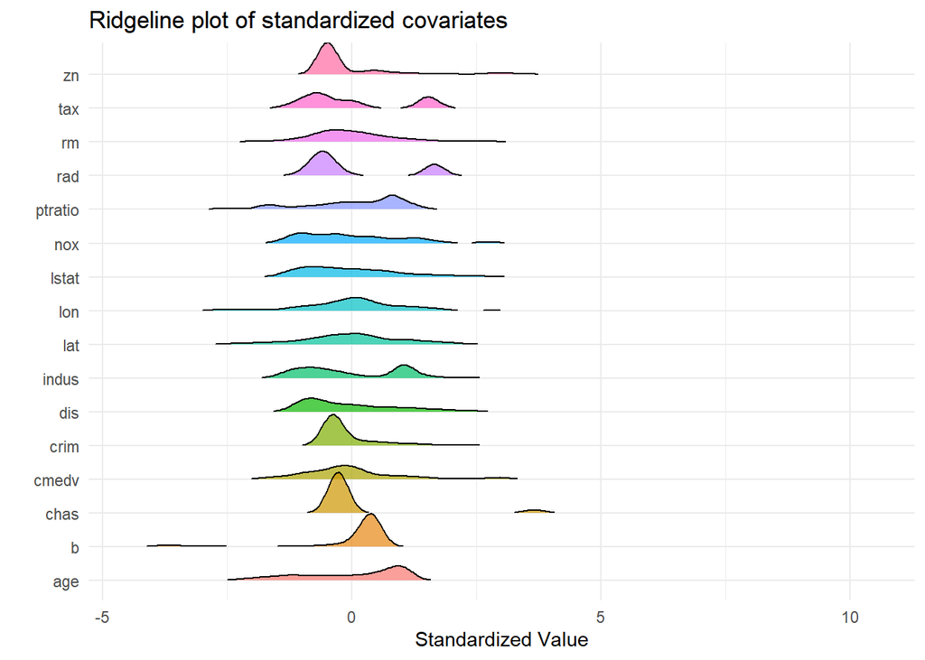

```r
# Ridgeline plot
library(ggplot2)
library(ggridges)
library(tidyr)  # or library(reshape2)
library(dplyr)
bhousing_long <- as.data.frame(scale(bhousing)) %>%     # Convert to long format
  pivot_longer(cols = everything(), names_to = "Variable", values_to = "Value")

ggplot(bhousing_long, aes(x = Value, y = Variable, fill = Variable)) +
  geom_density_ridges(scale = 1.2, alpha = 0.7, rel_min_height = 0.01, show.legend = FALSE) +
  labs(title = "Ridgeline plot of standardized covariates", x = "Standardized Value", y = "") +
  theme_minimal()
```

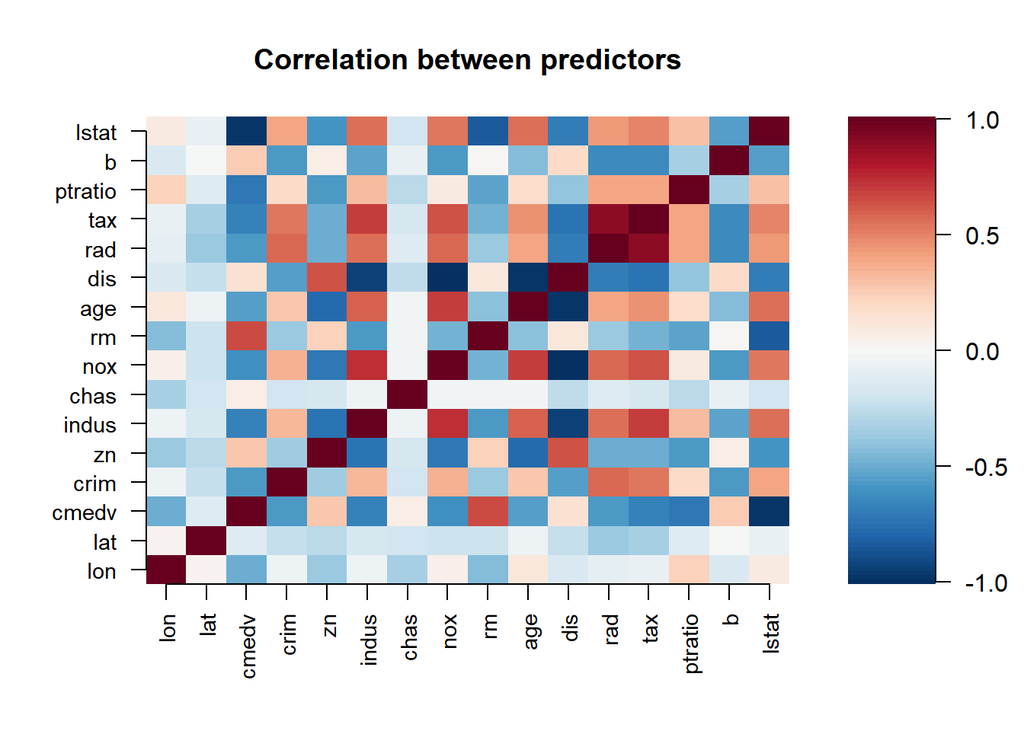

```r
# Correlation matrix:
library(RColorBrewer)
# Divergent palette: blue -> white -> red
pal <- colorRampPalette(rev(brewer.pal(11, "RdBu")))(100)
layout(matrix(c(1,2), nrow=1), widths=c(4,1))
par(mar=c(5,5,4,1))
image(1:ncol(bhousing),1:ncol(bhousing),cor(bhousing),
      xlab="",ylab="",main="Correlation between predictors",
      col=pal, axes=FALSE)
axis(1,1:ncol(bhousing),colnames(bhousing),las=2,cex.axis=0.9)
axis(2,1:ncol(bhousing),colnames(bhousing),las=2,cex.axis=0.9)
# Colorbar
par(mar=c(5,1,4,3))
z <- seq(-1, 1, length.out=100)
image(1, z, matrix(z, nrow=1), col=pal,
      axes=FALSE, xlab="", ylab="")
axis(4, las=2)
```

The boxplots illustrate the presence of several extreme observations in many variables. In general, these observations could be quite insightful and should require further investigation when they are a few.

In this case, since we notice a substantial number of observations located far from the medians, we rather conclude that the variables display a strong skewness (e.g. `crim` and `b`) or kurthosis (e.g. `lon`, `lat`, and `rm`).

The correlation matrix suggests that a positive linear relationship exists between `cmedv` and `rm`, and in a lesser way with `zn` and `b`, and a negative one between `cmedv` and `ptratio` and `lstat`. It follows that these may be good predictors of `cmedv`.

We consider the following linear regression model with the **horseshoe** shrinkage prior of [Carvalho, Polson and Scott (2010)](https://www.jstor.org/stable/25734098?seq=1) on the regression coefficients:

$$\begin{split}
& y_i \sim \mathscr{N}(\alpha+ X_i \beta,\sigma^2) \\
& \alpha \sim \mathscr{N}(0,100) \\
& \beta_j \mid \lambda_j,\tau \sim \mathscr{N}\!\left(0,\,
\lambda_j^{2}\,\tau^{2}\right) \\
& \lambda_j \sim \mathscr{C}^{+}(0,1), \qquad j=1,\dots,p \\
& \tau \sim \mathscr{C}^{+}(0,1) \\
& \sigma^{-2} \sim \mathscr{G}a(0.01,0.01) \\
\end{split}$$

where $\mathscr{C}^{+}(0,1)$ denotes the standard half-Cauchy distribution (a Cauchy truncated to the positive real line). This is the canonical horseshoe formulation: a **global–local** scale-mixture of Gaussians with a global shrinkage parameter $\tau$ shared across all coefficients and a *local* shrinkage parameter $\lambda_j$ for each $\beta_j$.

The horseshoe is named after the implied prior on the shrinkage weight $\kappa_j = 1/(1+\lambda_j^2)$, which under $\lambda_j \sim \mathscr{C}^+(0,1)$ follows a $\mathscr{B}eta(1/2,1/2)$ density: a “horseshoe”-shaped curve with mass piling up at both $\kappa_j \approx 0$ (no shrinkage, signal preserved) and $\kappa_j \approx 1$ (total shrinkage, coefficient pulled to zero).

This behaviour is exactly what we want for sparse regression with many possibly irrelevant predictors:

- The **infinite spike at zero** of the implied marginal $\pi(\beta_j)$ provides aggressive shrinkage for the truly null coefficients;
- The **Cauchy-like polynomial tails** leave large signals essentially un-shrunk a posteriori, avoiding the over-shrinkage of strong effects that Gaussian and Laplace priors suffer from;
- The global $\tau$ adapts the overall sparsity level to the data, while the local $\lambda_j$ allow coefficient-specific deviations from that overall level.

```r
# Model settings:
Y = bhousing$cmedv
X = within(bhousing,rm("cmedv","lon","lat"))
p = ncol(X)
n = nrow(X)

# Standardize the covariates to improve mixing of the MCMC (the horseshoe is sensitive to scale)
Y = as.numeric(scale(Y))
X = scale(X)

# Define the list:
dataList = list(Y=Y,X=X,n=n,p=p)

# Write the model specification:
model_string = textConnection(
"model{

   # Likelihood
   for(i in 1:n){
      Y[i] ~ dnorm(alpha + inprod(X[i,], beta[]), inv.var)
   }

    # Horseshoe prior on the regression coefficients
    # beta_j | lambda_j, tau ~ N(0, lambda_j^2 * tau^2)
    for(j in 1:p){
      beta[j] ~ dnorm(0, prec.beta[j])
      prec.beta[j] = 1 / (lambda[j] * lambda[j] * tau * tau)

      # Local shrinkage: half-Cauchy(0, 1)
      # In JAGS, half-Cauchy = Student-t with 1 d.f. truncated to positives
      lambda[j] ~ dt(0, 1, 1) T(0, )
    }

    # Global shrinkage: half-Cauchy(0, 1)
    tau ~ dt(0, 1, 1) T(0, )

    # Intercept and residual precision
    alpha ~ dnorm(0, 0.01)
    inv.var ~ dgamma(0.01, 0.01)

    # Variance of the residuals (for monitoring)
    sigma2 = 1 / inv.var

 }")
```

Notice that BUGS requires the precision, instead of the variance, to define the normal distribution.

With little implementation effort we are ready to estimate the model. We can modify the settings, e.g. the burn in period `burn`, total number of iterations `n.iter`, number of adaptations `n.adapt`, the thinning `thin`, and number of chains to be produced `n.chains`.

```r
# Set the options.
# The horseshoe mixes more slowly than the Gaussian hierarchical prior because of
# the heavy-tailed half-Cauchy priors on lambda_j and tau, so we use a longer
# burn-in, more adaptation iterations and stronger thinning.
burn = 10000
n.iter = 20000
#n.iter = 100000
n.adapt = 1000
thin = 10
#thin = 100
n.chains = 4

# Create a `jags` object:
model = jags.model(model_string,data=dataList,n.chains=n.chains,n.adapt=n.adapt)
# Check for convergence:
update(model,n.iter=burn)

# Save the output according to the arguments:
samples = coda.samples(model,variable.names=c("alpha","beta","sigma2","tau","lambda"),thin=thin,n.iter=n.iter)
```

We have saved the output in `samples`, where the chains are stored. The details of the model are stored in `model`. Using `summary` we can view the details concerning the samples that were produced and the empirical mean, standard deviation, and quantiles of the parameter distributions.

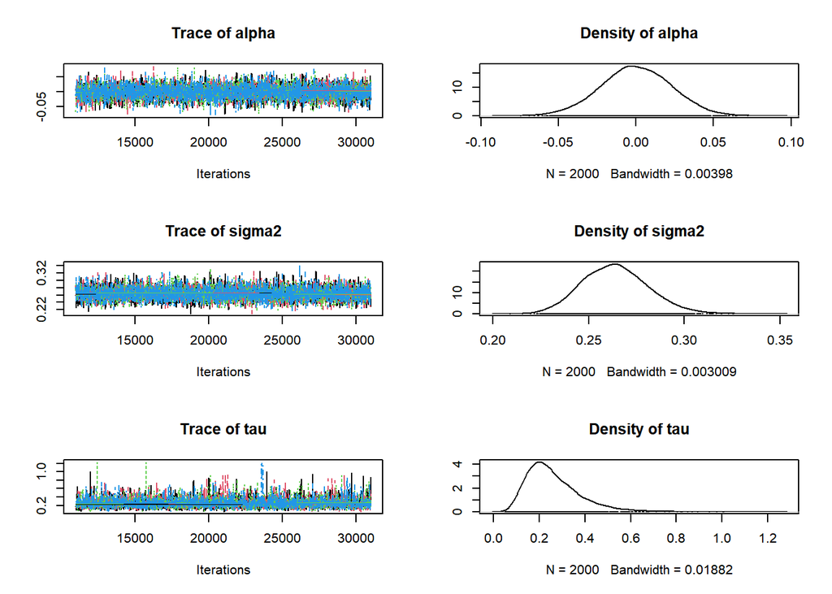

```r
# Trace plots and posterior densities.
# coda orders columns alphabetically: alpha, beta[1..p], lambda[1..p], sigma2, tau.
varnames_all = varnames(samples)

# Trace + density for the intercept, residual variance and the global shrinkage tau
plot(samples[, c("alpha", "sigma2", "tau")])
```

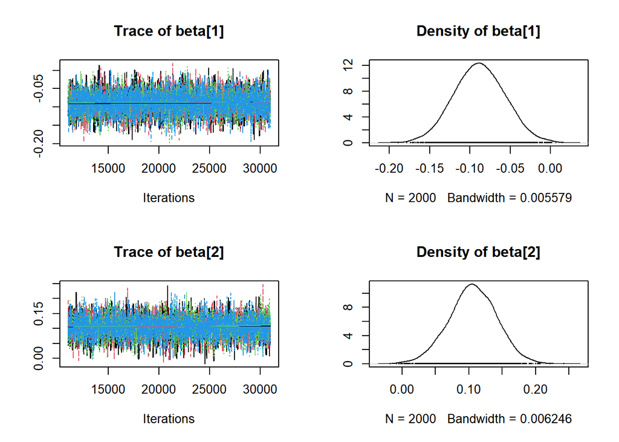

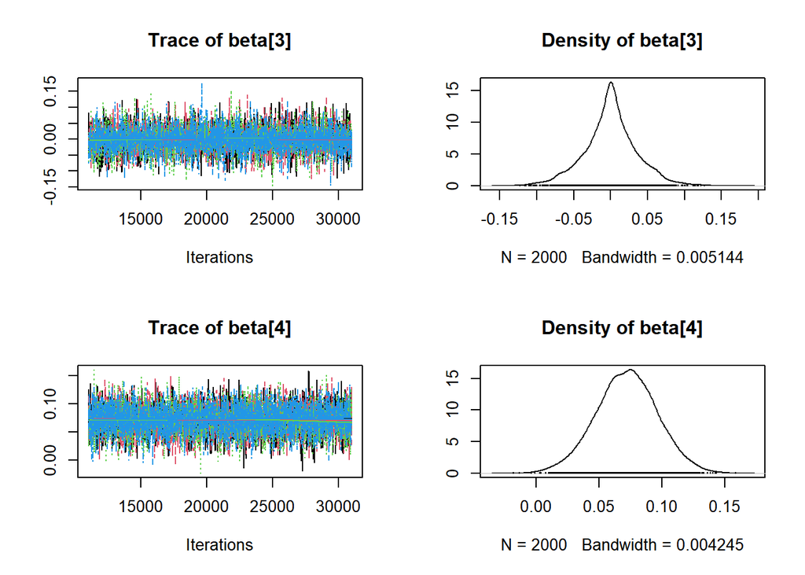

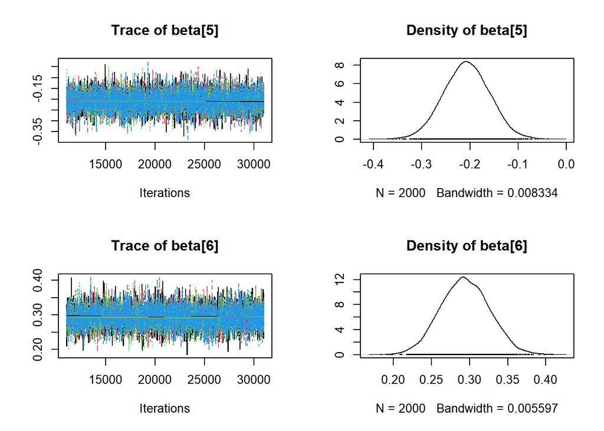

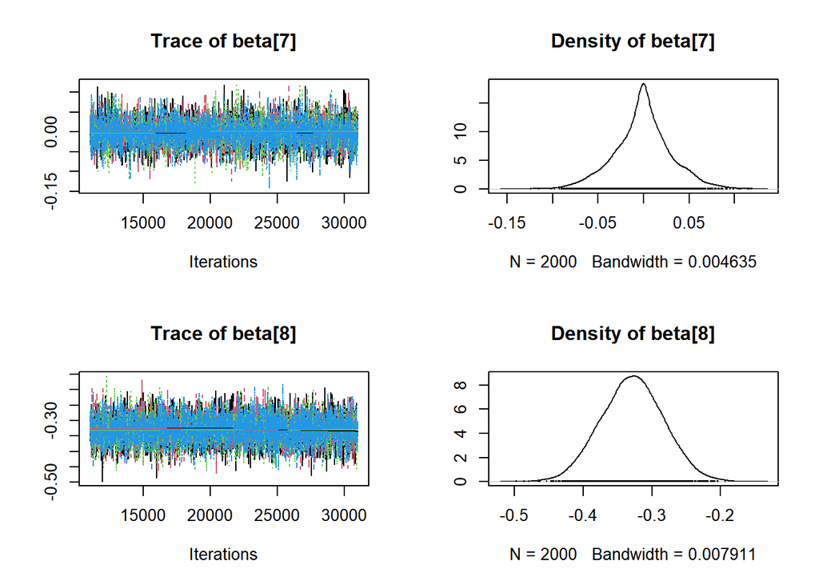

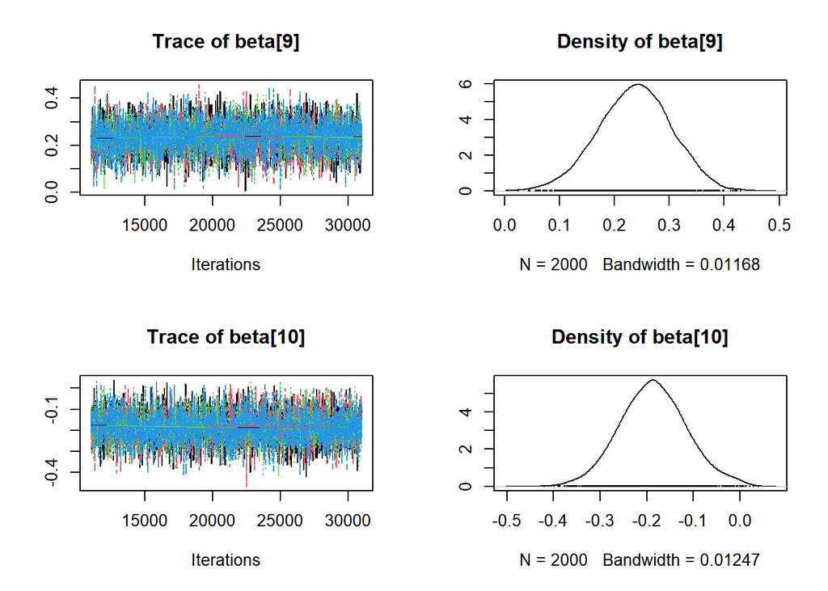

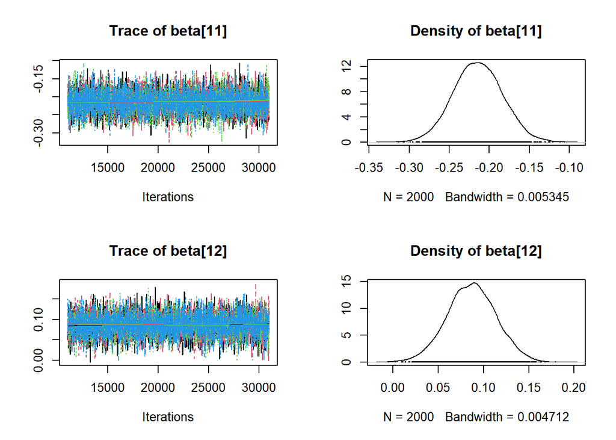

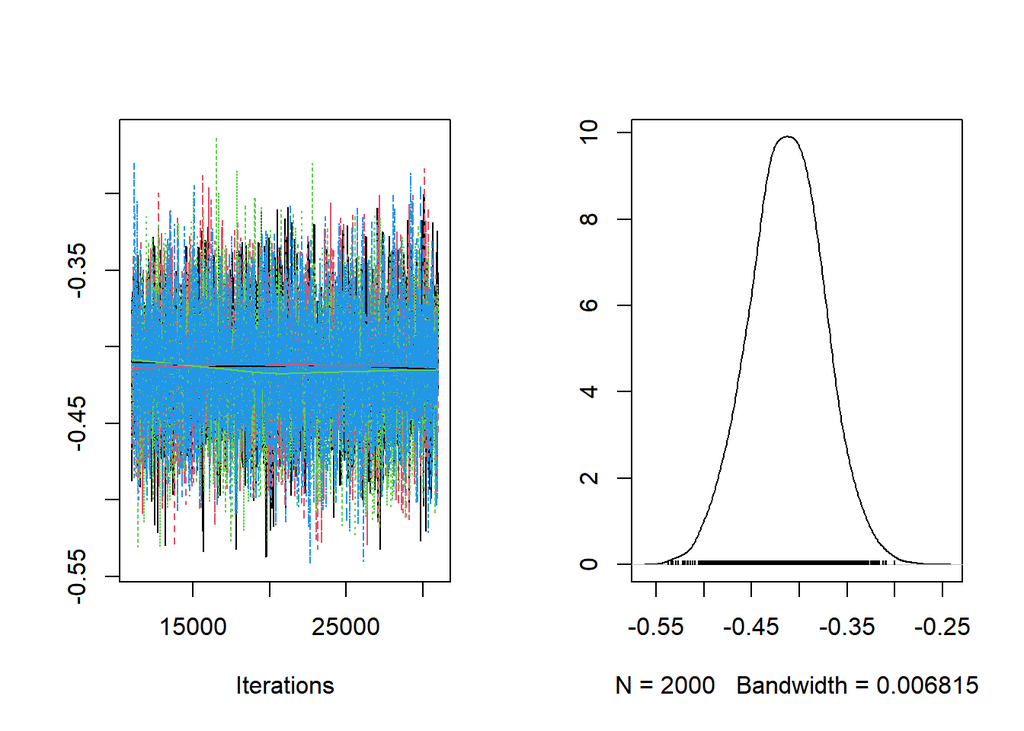

```r
# Trace + density for the regression coefficients
beta_idx = grep("^beta\\[", varnames_all)
for(k in seq(1, length(beta_idx), by = 2)){
  idx = beta_idx[k:min(k + 1, length(beta_idx))]
  plot(samples[, idx])
}
```

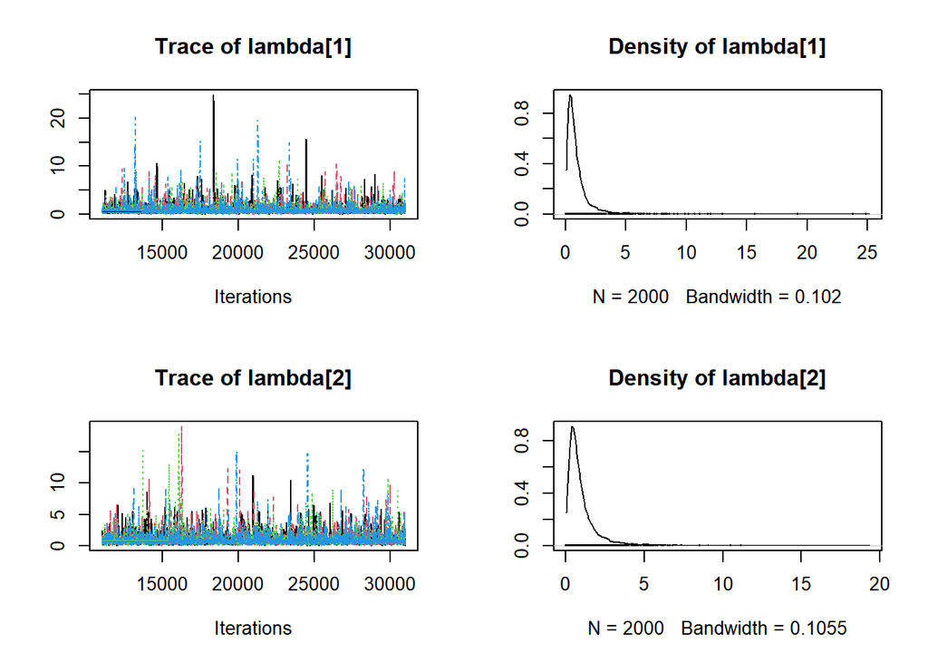

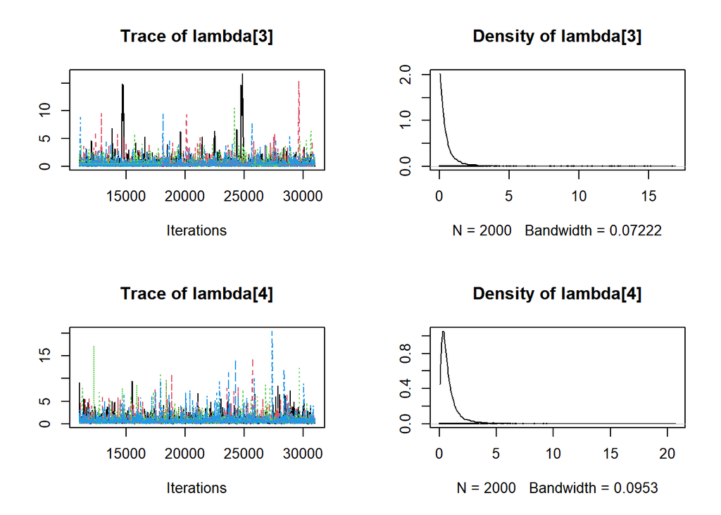

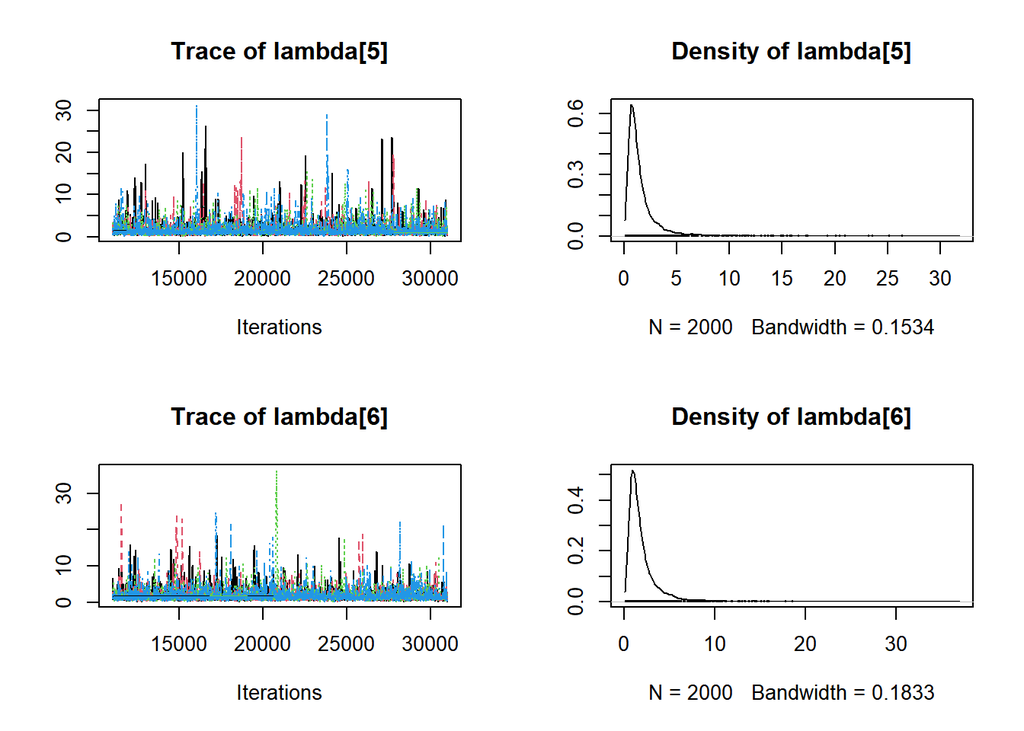

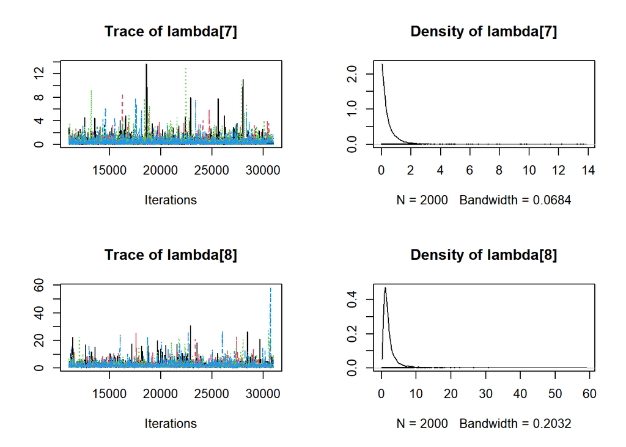

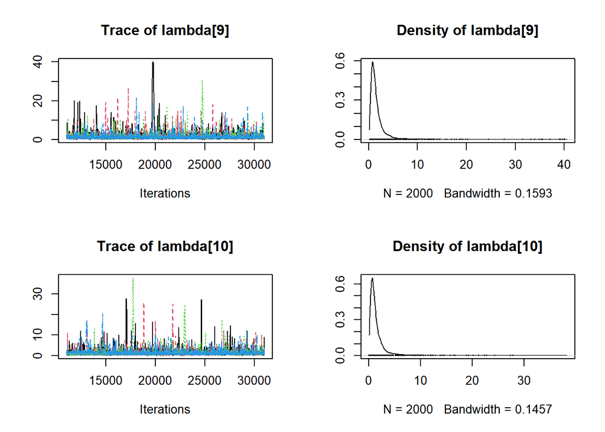

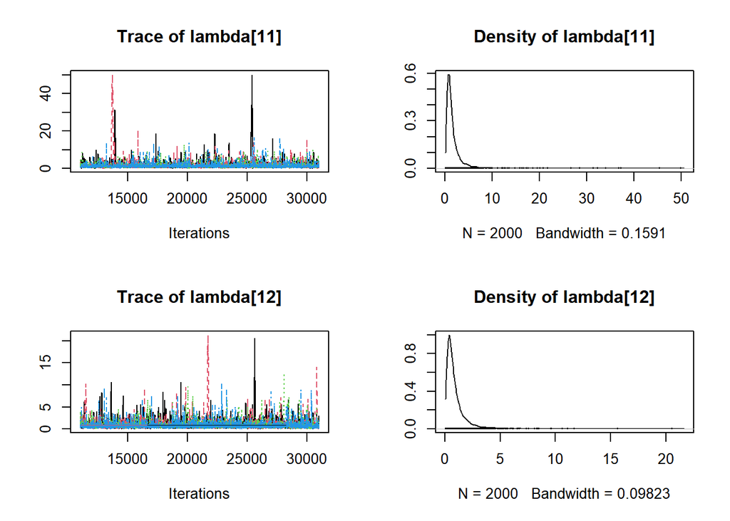

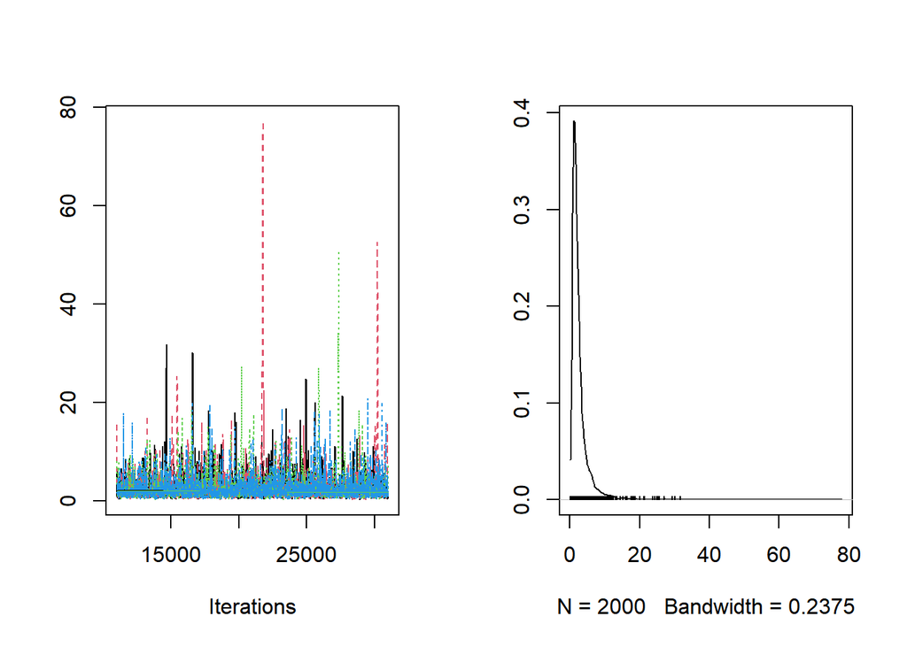

```r
# Trace + density for a few local shrinkage parameters lambda_j
lambda_idx = grep("^lambda\\[", varnames_all)
for(k in seq(1, length(lambda_idx), by = 2)){
  idx = lambda_idx[k:min(k + 1, length(lambda_idx))]
  plot(samples[, idx])
}
```

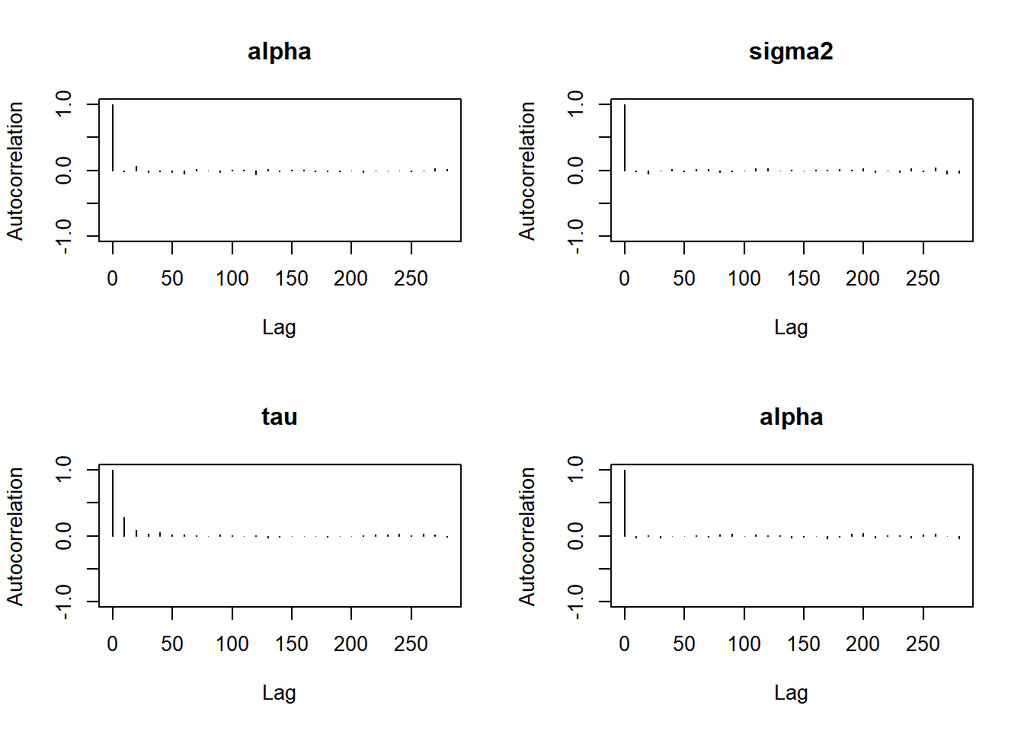

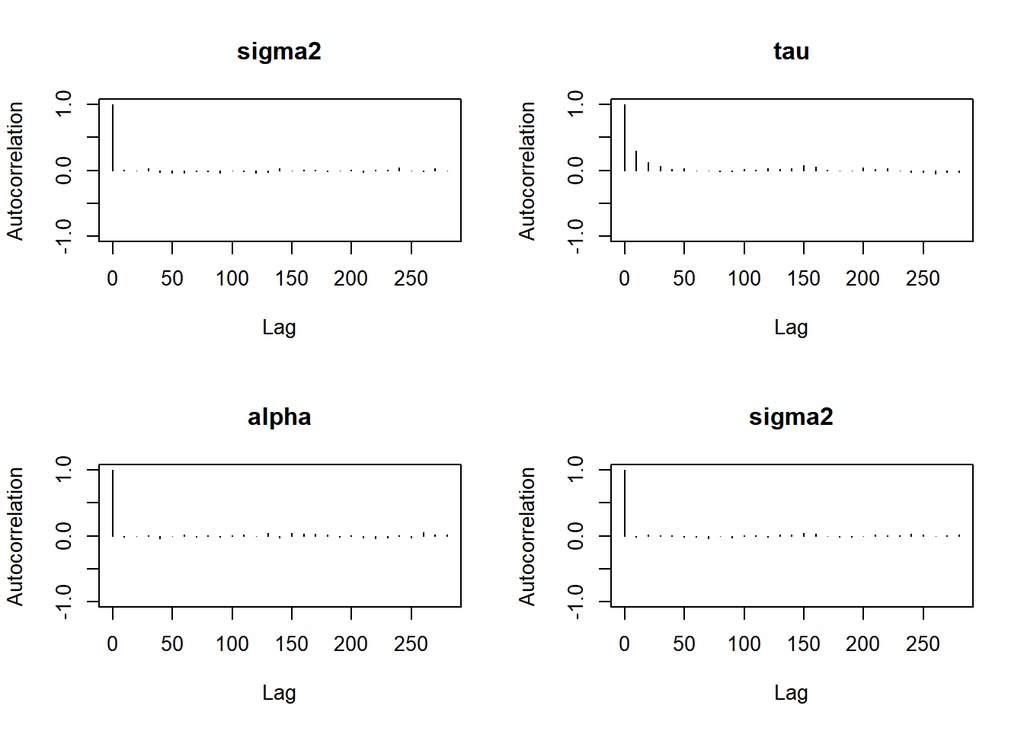

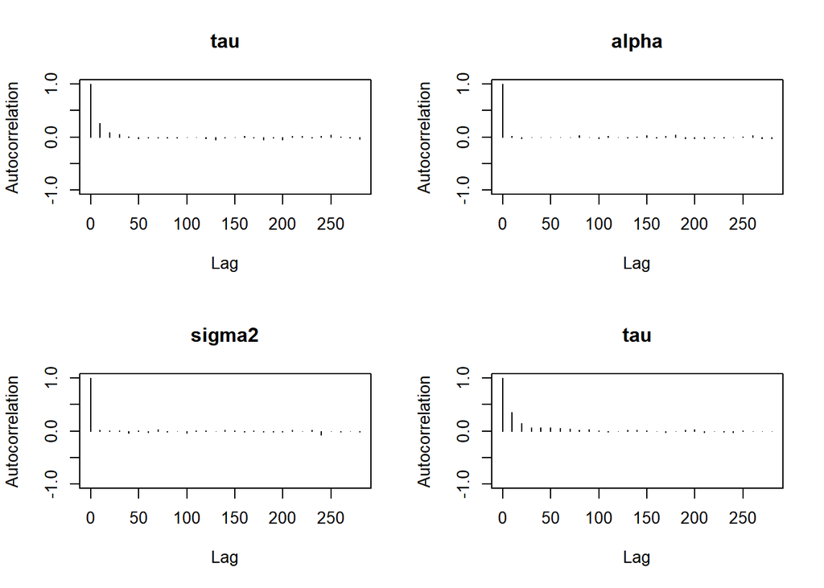

```r
# Autocorrelation function: heavy-tailed half-Cauchy priors typically yield
# higher autocorrelation than Gaussian priors, so this is worth inspecting.
autocorr.plot(samples[, c("alpha", "sigma2", "tau")])
```

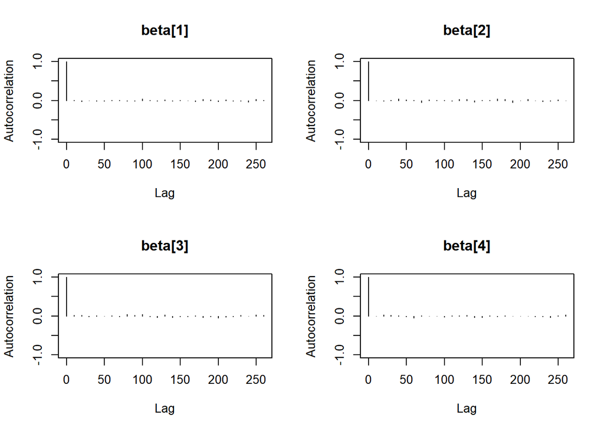

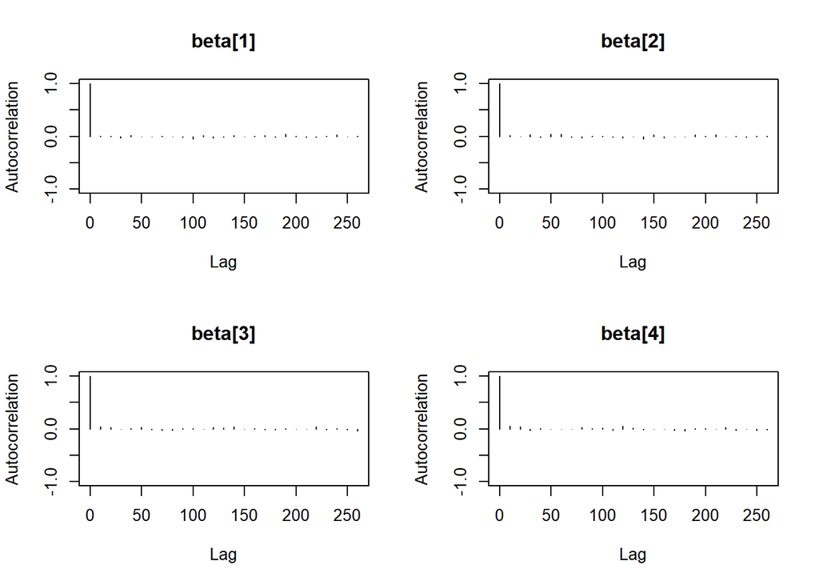

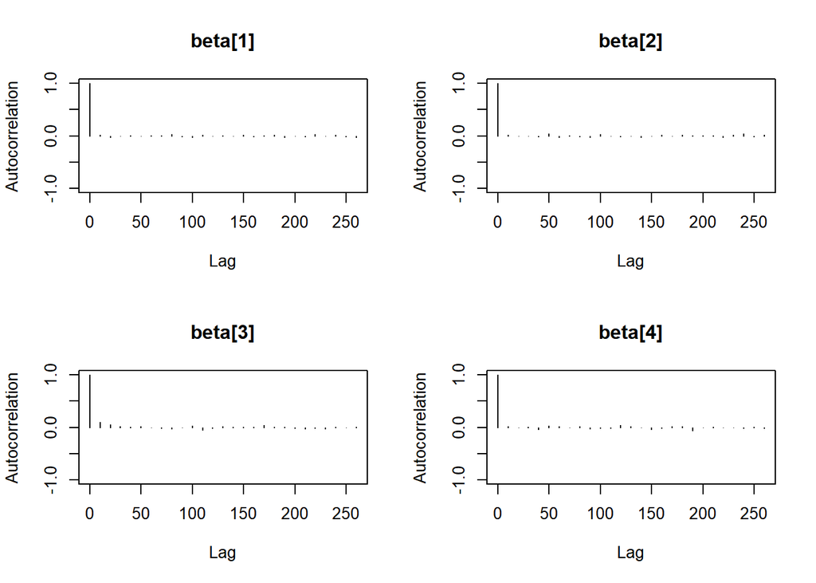

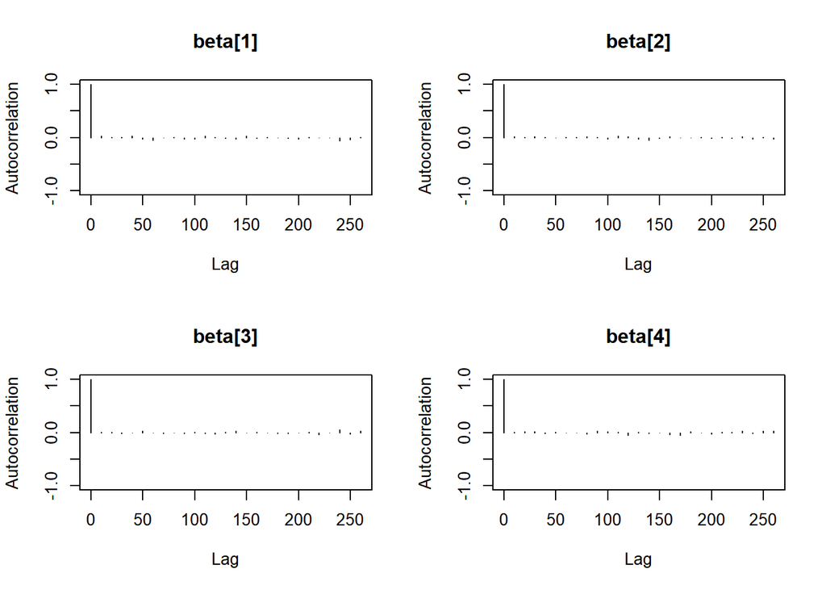

```r
autocorr.plot(samples[, beta_idx[1:min(4, length(beta_idx))]])
```

Through the trace plots we aim to evaluate the [**mixing**](https://en.wikipedia.org/wiki/Markov_chain_mixing_time) of the samples. It relates to the speed by which the sequence of draws converges to the stationary distribution, in our case being the full conditional posterior.

```r
# Complete summary:
summary(samples)
```

```
##
## Iterations = 11010:31000
## Thinning interval = 10
## Number of chains = 4
## Sample size per chain = 2000
##
## 1. Empirical mean and standard deviation for each variable,
##    plus standard error of the mean:
##
##                  Mean      SD  Naive SE Time-series SE
## alpha      -1.097e-05 0.02266 0.0002533      0.0002445
## beta[1]    -8.840e-02 0.03176 0.0003551      0.0003551
## beta[2]     1.059e-01 0.03585 0.0004008      0.0004008
## beta[3]    -1.819e-04 0.03605 0.0004030      0.0004245
## beta[4]     7.180e-02 0.02442 0.0002730      0.0002801
## beta[5]    -2.072e-01 0.04744 0.0005304      0.0005357
## beta[6]     2.941e-01 0.03186 0.0003562      0.0003490
## beta[7]    -9.409e-04 0.03169 0.0003544      0.0003407
## beta[8]    -3.287e-01 0.04503 0.0005035      0.0004981
## beta[9]     2.368e-01 0.06648 0.0007432      0.0010048
## beta[10]   -1.859e-01 0.07188 0.0008036      0.0011367
## beta[11]   -2.141e-01 0.03043 0.0003402      0.0003451
## beta[12]    8.680e-02 0.02682 0.0002999      0.0003001
## beta[13]   -4.131e-01 0.03880 0.0004337      0.0004152
## lambda[1]   1.024e+00 1.36864 0.0153019      0.0275253
## lambda[2]   1.071e+00 1.30105 0.0145462      0.0242885
## lambda[3]   6.174e-01 1.13150 0.0126505      0.0374642
## lambda[4]   9.041e-01 1.16744 0.0130524      0.0203359
## lambda[5]   1.691e+00 2.08019 0.0232572      0.0459054
## lambda[6]   2.024e+00 2.16234 0.0241757      0.0433471
## lambda[7]   5.217e-01 0.84343 0.0094298      0.0189625
## lambda[8]   2.291e+00 2.68152 0.0299803      0.0590790
## lambda[9]   1.842e+00 2.56887 0.0287209      0.0803743
## lambda[10]  1.579e+00 2.24295 0.0250769      0.0615405
## lambda[11]  1.750e+00 2.53305 0.0283203      0.0801944
## lambda[12]  9.764e-01 1.22915 0.0137423      0.0261335
## lambda[13]  2.700e+00 3.51841 0.0393370      0.0949013
## sigma2      2.639e-01 0.01713 0.0001915      0.0001887
## tau         2.625e-01 0.12261 0.0013708      0.0018920
##
```

[output cut: 17 more lines]

```
## lambda[1]   0.13085  0.37315  0.6517756  1.15088  4.36342
## lambda[2]   0.14622  0.41914  0.7107237  1.22393  4.30380
## lambda[3]   0.01004  0.12195  0.3102515  0.67285  3.00039
## lambda[4]   0.10544  0.31996  0.5782093  1.04693  3.77354
## lambda[5]   0.30156  0.69357  1.1049138  1.86345  6.93376
## lambda[6]   0.42033  0.91981  1.4277808  2.31790  7.35597
## lambda[7]   0.01095  0.10689  0.2756858  0.62863  2.41872
## lambda[8]   0.45831  0.98095  1.5464704  2.53085  9.01982
## lambda[9]   0.32643  0.75287  1.1875884  1.96780  7.78211
## lambda[10]  0.21786  0.60910  1.0009223  1.72089  6.59787
## lambda[11]  0.31891  0.72902  1.1529538  1.94253  6.43981
## lambda[12]  0.12895  0.37501  0.6445672  1.12431  3.94417
## lambda[13]  0.55502  1.17576  1.8357487  2.98722 10.12717
## sigma2      0.23225  0.25178  0.2632952  0.27486  0.29979
## tau         0.09930  0.17788  0.2370443  0.32143  0.56222
```

Recall that the naive standard error is the standard deviation ($SD$) of a coefficient estimate $\hat{\beta}_j$:

$$\text{Naive SE} = \frac{\text{SD}(\hat{\beta}_j)}{\sqrt{S}}$$
where $S$ is the number of MCMC samples. `Time-series SE` is the corrected standard error of the mean, accounting for autocorrelation between samples, where in practice the posterior standard deviations are divided by the effective sample size.

Indeed, if the samples appeared to be autocorrelated over time, we might desire to increase even more the number of iterations and burn-in period to get less dependence among subsequent draws (at the cost of increasing the computational time).

The effective sample size (ESS) measures how much information content is loss due to the correlation in the sequence. In fact, we expect that our effective sample size will be smaller than the observed sample size when the autocorrelation is large.

The ESS thus returns the number of independent samples with the same estimation power as the `n.iter` autocorrelated samples obtained from the MCMC. According to its definition, it is desirable to have an ESS that is close, or even larger than the sample size `n`. On the other hand, it goes to zero if the autocorrelation in the chain is substantial.

```r
# Effective sample size
effectiveSize(samples)
```

```
##      alpha    beta[1]    beta[2]    beta[3]    beta[4]    beta[5]    beta[6]
##   8744.543   8000.000   8000.000   7338.573   7655.678   7853.605   8355.381
##    beta[7]    beta[8]    beta[9]   beta[10]   beta[11]   beta[12]   beta[13]
##   8745.617   8189.171   4383.368   4002.798   7847.942   8003.285   8746.528
##  lambda[1]  lambda[2]  lambda[3]  lambda[4]  lambda[5]  lambda[6]  lambda[7]
##   2994.813   3475.878   2084.074   4019.528   2659.620   2781.089   3098.522
##  lambda[8]  lambda[9] lambda[10] lambda[11] lambda[12] lambda[13]     sigma2
##   2854.205   1984.608   1417.291   2764.757   3103.071   2594.943   8266.288
##        tau
##   4235.207
```

```r
# Gelman-Rubin diagnostic: values close to 1 indicate convergence across chains
gelman.diag(samples)
```

```
## Potential scale reduction factors:
##
##            Point est. Upper C.I.
## alpha            1.00       1.00
## beta[1]          1.00       1.00
## beta[2]          1.00       1.00
## beta[3]          1.00       1.00
## beta[4]          1.00       1.00
## beta[5]          1.00       1.00
## beta[6]          1.00       1.00
## beta[7]          1.00       1.00
## beta[8]          1.00       1.00
## beta[9]          1.00       1.00
## beta[10]         1.00       1.00
## beta[11]         1.00       1.00
## beta[12]         1.00       1.00
## beta[13]         1.00       1.01
## lambda[1]        1.02       1.02
## lambda[2]        1.01       1.01
## lambda[3]        1.06       1.07
## lambda[4]        1.04       1.04
## lambda[5]        1.02       1.02
## lambda[6]        1.02       1.02
## lambda[7]        1.04       1.05
## lambda[8]        1.03       1.03
## lambda[9]        1.05       1.06
## lambda[10]       1.03       1.04
## lambda[11]       1.08       1.09
## lambda[12]       1.02       1.02
## lambda[13]       1.08       1.09
## sigma2           1.00       1.00
## tau              1.00       1.00
##
## Multivariate psrf
##
## 1.01
```

Although for Lambda we are not in perfect shape, we are for beta, which is the parameter that we are mostly interested in. We can accept this, but if we wanted to improve the mixing of Lambda, we could increase the number of iterations, and/or use stronger thinning.

A diagnostic that is specific to the horseshoe is the posterior of the **shrinkage weights**
$$\kappa_j = \frac{1}{1 + \lambda_j^{2}}.$$
Values of $\kappa_j$ close to $1$ indicate that the $j$-th coefficient is being aggressively shrunk towards zero (noise), while values close to $0$ indicate the $j$-th coefficient is essentially unshrunk (signal). The “horseshoe” name comes from the U-shape of the implied prior $\kappa_j \sim \mathscr{B}eta(1/2, 1/2)$, with mass piled up at both ends.

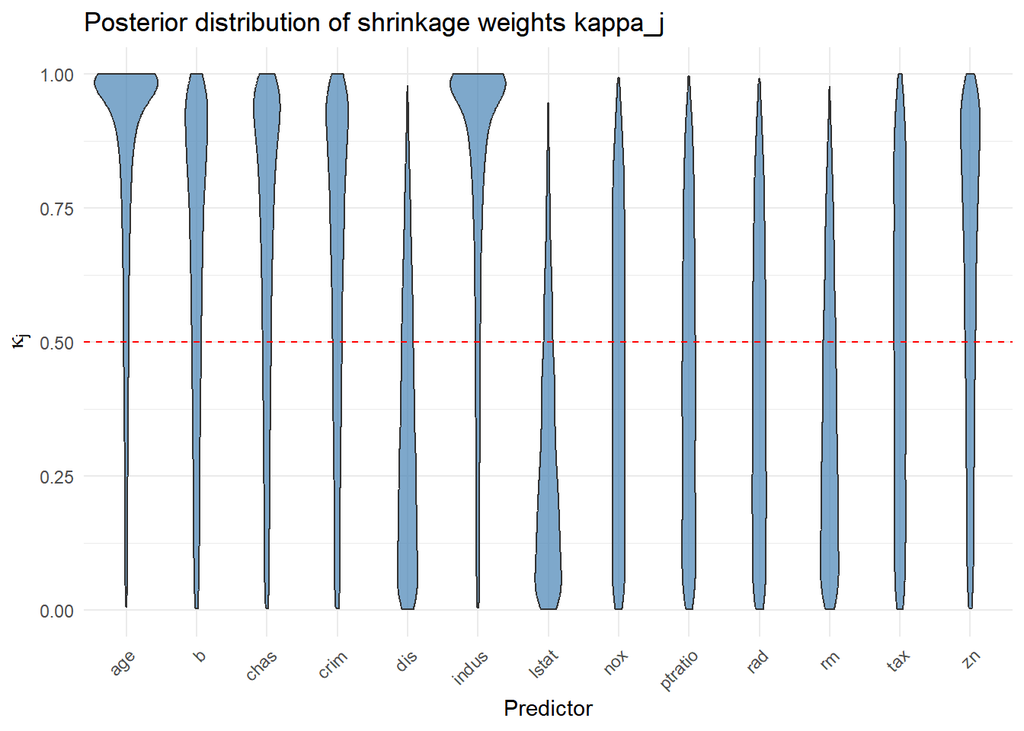

```r
# Posterior of the shrinkage weights kappa_j = 1 / (1 + lambda_j^2)
samp_mat   = as.matrix(samples)
lambda_mat = samp_mat[, grep("^lambda\\[", colnames(samp_mat))]
kappa_mat  = 1 / (1 + lambda_mat^2)

# Visualize the posterior through violin plots
library(ggplot2)
kappa_df = as.data.frame(kappa_mat)
colnames(kappa_df) = colnames(within(bhousing, rm("cmedv", "lon", "lat")))
kappa_long = pivot_longer(kappa_df, cols = everything(), names_to = "Predictor", values_to = "Kappa")
ggplot(kappa_long, aes(x = Predictor, y = Kappa)) +
  geom_violin(fill = "steelblue", alpha = 0.7) +
  geom_hline(yintercept = 0.5, color = "red", linetype = "dashed") +
  labs(title = "Posterior distribution of shrinkage weights kappa_j",
       x = "Predictor",
       y = expression(kappa[j])) +
  theme_minimal() +
  theme(axis.text.x = element_text(angle = 45, hjust = 1))
```

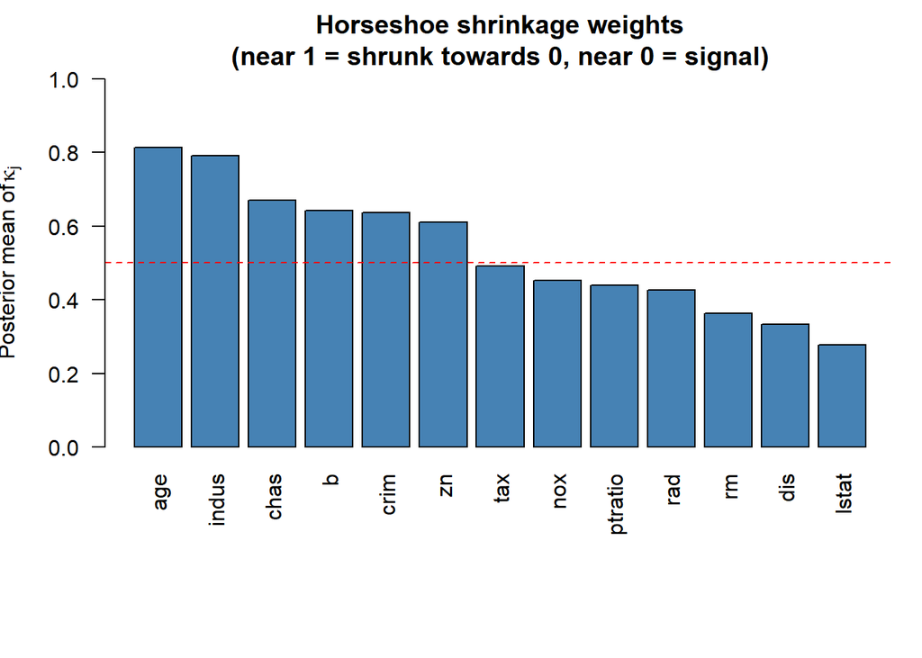

```r
# Posterior mean of kappa_j for each predictor
post_kappa = colMeans(kappa_mat)
names(post_kappa) = colnames(within(bhousing, rm("cmedv", "lon", "lat")))

# Visualise: bars near 1 = shrunk (likely null), bars near 0 = signal
par(mar = c(8, 4, 3, 1))
barplot(sort(post_kappa, decreasing = TRUE),
        las   = 2,
        col   = "steelblue",
        ylim  = c(0, 1),
        ylab  = expression("Posterior mean of " * kappa[j]),
        main  = "Horseshoe shrinkage weights\n(near 1 = shrunk towards 0, near 0 = signal)")
abline(h = 0.5, col = "red", lty = 2)
```

To complete let’s look in particular to the posterior for the regression coefficients associated to age, to nox and to lstat, which are the three cases representative of the three different scenarios that we can encounter with the horseshoe prior:

```r
# list the name of the variables in order
colnames(X)
```

```
##  [1] "crim"    "zn"      "indus"   "chas"    "nox"     "rm"      "age"
##  [8] "dis"     "rad"     "tax"     "ptratio" "b"       "lstat"
```

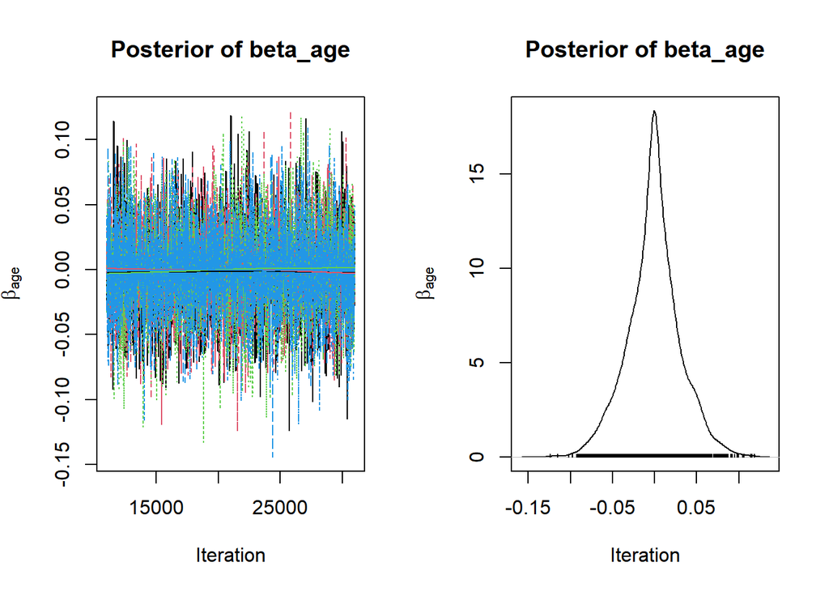

```r
# Posterior of beta_age, beta_rm and beta_rad
beta_age = samples[, "beta[7]"]
beta_nox  = samples[, "beta[5]"]
beta_lstat = samples[, "beta[12]"]

par(mfrow = c(1, 3))
plot(beta_age, main = "Posterior of beta_age", xlab = "Iteration", ylab = expression(beta[age]))
```

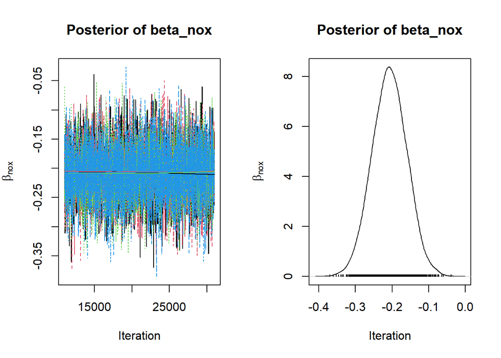

```r
plot(beta_nox, main = "Posterior of beta_nox", xlab = "Iteration", ylab = expression(beta[nox]))
```

[figure not shown]

```r
plot(beta_lstat, main = "Posterior of beta_lstat", xlab = "Iteration", ylab = expression(beta[lstat]))
```

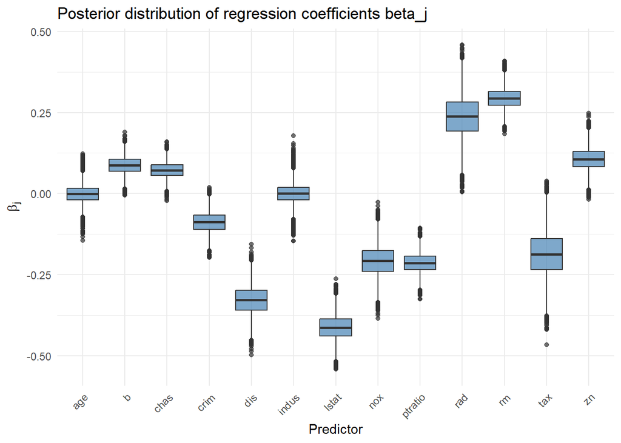

```r
# boxplot of all the regression coefficients
beta_idx = grep("^beta\\[", varnames_all)
beta_df = as.data.frame(samp_mat[, beta_idx])
colnames(beta_df) = colnames(within(bhousing, rm("cmedv", "lon", "lat")))
beta_long = pivot_longer(beta_df, cols = everything(), names_to = "Predictor", values_to = "Beta")
ggplot(beta_long, aes(x = Predictor, y = Beta)) +
  geom_boxplot(fill = "steelblue", alpha = 0.7) +
  labs(title = "Posterior distribution of regression coefficients beta_j",
       x = "Predictor",
       y = expression(beta[j])) +
  theme_minimal() +
  theme(axis.text.x = element_text(angle = 45, hjust = 1))
```

# Example 3: *Binomial logistic regression*

A **generalized linear model** (GLM) is a generalization of the ordinary linear regression model where a **link function** is used to relate the response to a number of independent variables. For example, the logistic, probit, and Poisson regression belong to this broad class.

In particular, **logistic regression** commonly refers to a model for dichotomous data, that is when the dependent variable $y$ only takes values equal to 0 or 1. However, such a denomination is misleading because it comprises a broader class of models where the logistic function is used as the **link function**, e.g. the binomial and Bernoulli regressions.

In particular, for binary variables the standard linear model would predict values above 1 or below 0. Thus we employ the logistic, or logit link function to bound the response variable between 0 and 1,

$$\begin{align*}
z_i &= X\beta, \\
p_i &= \frac{1}{1+e^{-z_i}},
\end{align*}$$
where $z_i = \log\left(\frac{p_i}{1-p_i}\right)$ is also known as the log-odds ratio and $p_i\in[0,1]$ is the probability of $y_i$ being equal to 1 for the $i$-th observation, computed as the logit transformation of $z_i$.

We consider the binomial regression model,

$$\begin{align*}
& y_i \mid p_i \overset{ind}\sim \mathscr{B}in(p_i,k), \\
& \log\left(\frac{p_i}{1-p_i}\right) = x_i \beta, &\qquad
i=1,\ldots,n \\[15pt]
&\beta_j \overset{iid}\sim \mathscr{N}(0,100), &\qquad
j=1,\ldots,p
\end{align*}$$

where $k$ denotes the number of trials, taken as fixed, and we denote with $\text{logit}(p_i) = x_i \beta$ to relax the notation which is used to specify the model in the BUGS syntax.

We consider real mortality data to model the count of deaths for moths depending on the `sex` and given the `dose` of a poisonous substance. The data are taken from [Royla and Dorazio](https://www.mbr-pwrc.usgs.gov/pubanalysis/roylebook/chapters.htm), Chapter 2, which is available online. In our model we are interested in a sequence of $K = 20$ trials, thus we write the code accordingly.

```r
# Clear the workspace:
rm(list=ls())

# Set the seed:
set.seed(1)

# Load the packages:
library(rjags)
library(coda)

# Create the dependent variable:
Y = c(1, 4, 9, 13, 18, 20, 0, 2, 6, 10, 12, 16)

# Create the independent variables:
sex = c(rep("male", 6), rep("female", 6))
dose = rep(0:5, 2)
X = cbind(dose,sex=as.integer(sex=="male"))

# Settings

n = length(Y)
P = ncol(X)
k = 20

burn = 5000
n.iter = 2000
n.chains = 3
n.adapt = 100
thin = 2
```

We write the BUGS code, as done previously, for the model above.

```r
model_string = textConnection(
"model {

  # Likelihood
  for (i in 1:n) {
    Y[i] ~ dbin(p[i],k)
    logit(p[i]) = beta0 + X[i,] %*% beta
  }

  # Prior
  beta0 ~ dnorm(0,0.001)
  for (j in 1:P) {
    beta[j] ~ dnorm(0,0.01)
  }
}")
```

Therefore we fit the model. Notice that `n.chains = 3`, hence we will produce three different sequences of draws. This approach is good if the user wants to initialize sampling with different values, perhaps exploring better every region of the parameter support.

```r
# Set up the data
dataList = list(Y=Y,X=X,n=n,P=P,k=k)

# Compile the model
model = jags.model(model_string,data=dataList,n.chains=n.chains,n.adapt=n.adapt)
# Model burn-in phase
update(model,n.iter=burn)

# Sampling from the posterior
samples = coda.samples(model,variable.names=c("beta0","beta","p"),n.iter=n.iter,thin=thin)
```

The usual trace plot and density are exhibited as follows.

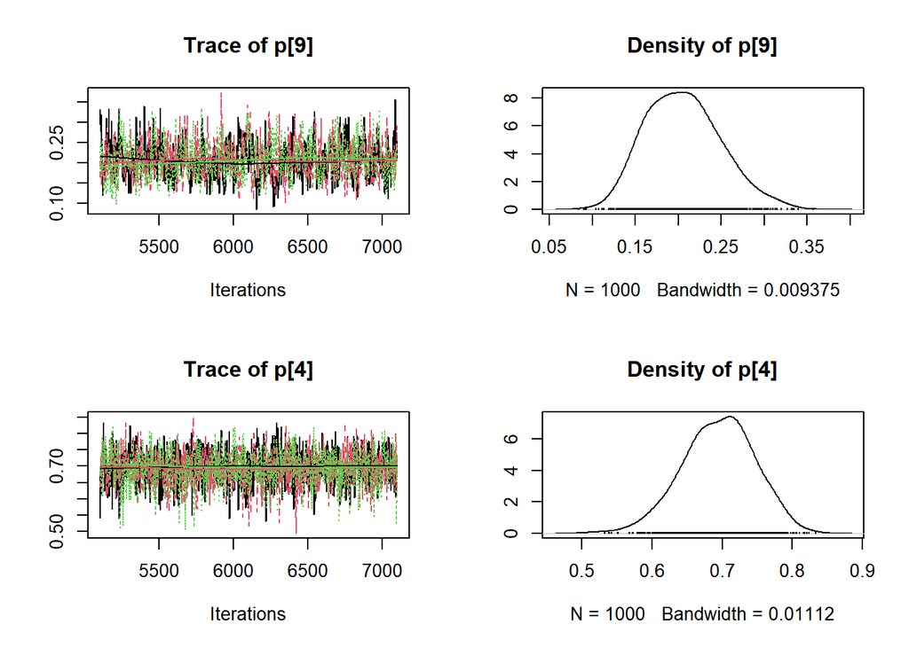

```r
# Plot the samples:
samples_idx = sample(4:15,2)
plot(samples[,samples_idx])
```

We compute the posterior mean and credible intervals for the intercept and two other coefficients. As shown below, this is quite easy. Notice that such metrics are computed based on all the chains, not only to a single one. Conversely, if one wants to produce them separately for each chain, she has to access e.g. the first chain as `samples[[1]]`.

```r
# Compute posterior mean and 95% CI
postMean = colMeans(as.matrix(samples))
CI = apply(as.matrix(samples),2,quantile,c(0.025, 0.975))
rbind("Mean"=postMean,CI)
```

```
##         beta[1]   beta[2]     beta0       p[1]      p[2]      p[3]      p[4]
## Mean  1.0896619 1.1149577 -3.550277 0.08508264 0.2105975 0.4372119 0.6946210
## 2.5%  0.8437223 0.4327287 -4.450688 0.03848355 0.1262794 0.3249354 0.5891126
## 97.5% 1.3559647 1.8026371 -2.668625 0.15108321 0.3097405 0.5524488 0.7890424
##            p[5]      p[6]       p[7]       p[8]      p[9]     p[10]     p[11]
## Mean  0.8683470 0.9495532 0.03070550 0.08251935 0.2059575 0.4310685 0.6889176
## 2.5%  0.7859415 0.9000597 0.01153590 0.04113541 0.1300786 0.3209828 0.5713773
## 97.5% 0.9277881 0.9791176 0.06485033 0.14438519 0.2993454 0.5415961 0.7903365
##           p[12]
## Mean  0.8646561
## 2.5%  0.7750797
## 97.5% 0.9299266
```

```r
# Alternatively
#summary(samples)
```

As a matter of fact, we can plot the density obtained from each chain separately as follows.

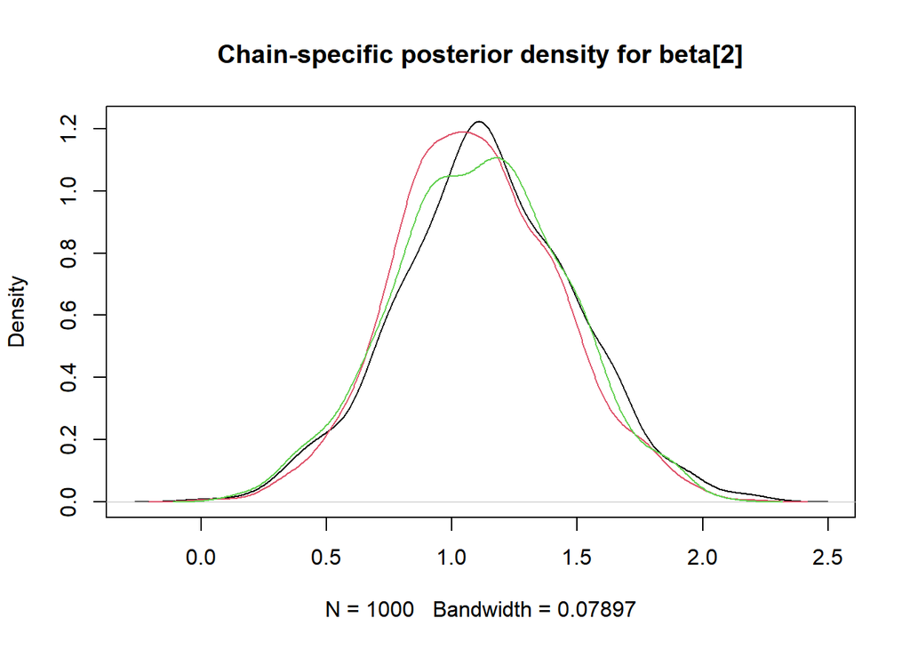

```r
# Set a color palette:
colorsPalette = palette(rainbow(n.chains))

# Plot the chain full conditional posteriors:
plot(density(unlist(samples[[1]][,"beta[2]"])),col=colorsPalette[1],
     main="Chain-specific posterior density for beta[2]")
for (j in 2:n.chains) {
  lines(density(unlist(samples[[j]][,"beta[2]"])),col=colorsPalette[j])
}
```

What are the effects of `dose` and `sex` on the deaths? Concerning `sex`, `beta[[2]]` is always positive, hence being males increases the probability of death compared to females. Relative to `dose`, we can help ourselves with the following graph where we display the probability of death across $K=20$ independent experiments.

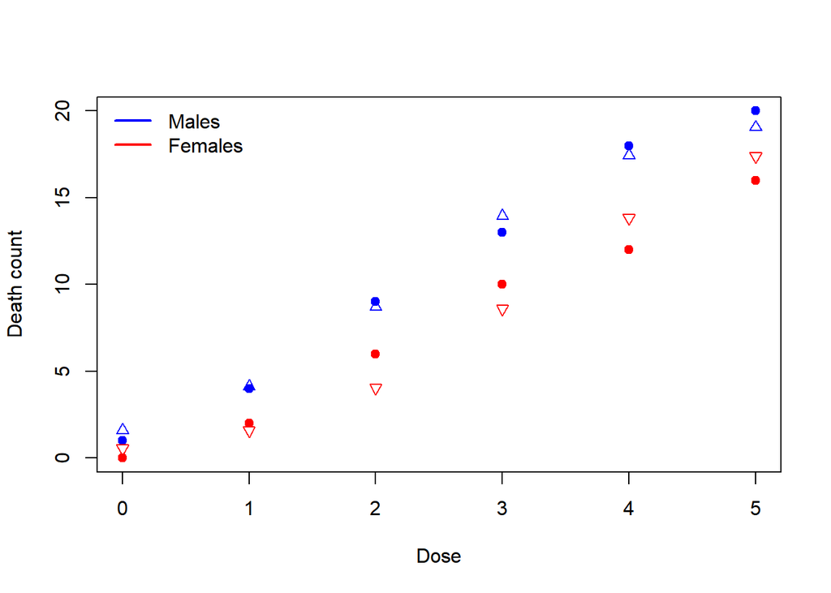

```r
# Set some variables:
orderDose = order(X[,1])
colorSex = ifelse(sex=='male','blue','red')

# Plot actual VS predicted number of deaths:
plot(X[,1],Y,pch=19,col=colorSex,xlab="Dose",ylab="Death count")
points(X[orderDose,1],
      k * boot::inv.logit(postMean[3]+postMean[2]*1+postMean[1]*X[orderDose,1]),
      col="blue",pch=2)                 # `inv.logit()` from the `boot` package
points(X[orderDose,1],
      k * boot::inv.logit(postMean[3]+postMean[2]*0+postMean[1]*X[orderDose,1]),
      col="red",pch=6)

legend("topleft",legend=c("Males","Females"),lty=1,lwd=2,col=c("blue","red"),bty="n")
```

In particular, we compare observed deaths with model-based predictions of expected deaths for males and females, across different doses. Recall that if $Y\sim\mathscr{Bin}(p,k)$, then $E(Y)=kp$. Therefore `k * inv.logit(beta0 + beta2*sex + beta1*dose)` computes the expected number of deaths.

By inspecting the graph we conclude that males and females both die more as the number of doses increase, but males display a higher mortality given the same number of doses, even when no dose is given.

## Exercise 1: Horseshoe shrinkage with the logistic regression

In Example 3 we fit the binomial logistic regression with vague Gaussian priors on the regression coefficients. When the number of covariates is large relative to the sample size, or when many predictors are expected to be irrelevant, those flat priors offer no protection against overfitting. The horseshoe prior of Example 2 is a natural remedy: it adapts the amount of shrinkage to each coefficient, leaving large signals essentially unshrunk while pulling noisy ones aggressively towards zero.

The model becomes
$$\begin{align*}
& y_i \mid p_i \overset{ind}\sim \mathscr{B}in(p_i, k), \\
& \log\left(\frac{p_i}{1-p_i}\right) = \beta_0 + x_i\,\beta, \\
& \beta_j \mid \lambda_j, \tau \overset{ind}\sim
\mathscr{N}\!\left(0,\, \lambda_j^{2}\,\tau^{2}\right), \qquad j = 1,
\dots, p \\
& \lambda_j \overset{iid}\sim \mathscr{C}^{+}(0,1), \\
& \tau \sim \mathscr{C}^{+}(0,1), \\
& \beta_0 \sim \mathscr{N}(0, 100).
\end{align*}$$

Using the moths mortality data of Example 3, complete the following tasks:

1. **Write the JAGS model.** Take the model from Example 2 as a template for the horseshoe block (priors on $\beta_j$, local $\lambda_j$ and global $\tau$) and replace the Gaussian likelihood with the binomial likelihood and the logit link of Example 3. There is no residual variance to estimate this time, since the binomial dispersion is fully determined by $p_i$ and $k$.
2. **Fit the model and assess convergence.** Be aware that the horseshoe mixes more slowly than vague Gaussian priors because of the heavy-tailed half-Cauchy hyperpriors: increase the burn-in, the number of iterations, and the thinning compared to Example 3. Inspect the trace plots, the effective sample size, the autocorrelation, and the Gelman–Rubin diagnostic.
3. **Visualize the shrinkage weights.** Compute the posterior of $\kappa_j = 1/(1+\lambda_j^{2})$ and display its distribution for each predictor. Identify which covariates are being aggressively shrunk (posterior mass of $\kappa_j$ near $1$) and which are essentially unshrunk (posterior mass near $0$).
4. **Compare with Example 3.** Plot the posterior means and 95% credible intervals of $\beta_j$ from the horseshoe model side by side with those from Example 3. Comment on the differences in point estimates and uncertainty: do the active coefficients agree? Does shrinkage tighten or widen the intervals for the apparently null effects?

```r
# Write you code here.
```

## Exercise 2: *Bernoulli regression*

Consider the Bernoulli regression model,

$$\begin{align*}
& y_i \mid p_i \overset{ind}\sim \mathscr{B}e(p_i), &\qquad
i=1,\ldots,n \\[15pt]
1) \quad & \log\left(\frac{p_i}{1-p_i}\right) = x_i \beta,
&\qquad \rightarrow\text{logistic link} \\
2) \quad & \Phi^{-1}(p_i) = x_i \beta, &\qquad
\rightarrow\text{probit link} \\[15pt]
&\beta_j \overset{iid}\sim \mathscr{N}(0,100), &\qquad
j=1,\ldots,p
\end{align*}$$

for responses $y_i$ that can take values equal to 0 or 1 and where the logistic or probit link function might be used. Notice that, in the probit case, $\Phi(\cdot)$ denotes the normal c.d.f. and, hence, $\Phi(\cdot)^{-1}$ its quantile.

We load the `titanic` dataset about the survival of the passengers of the Titanic; more information are available [here](https://cran.r-project.org/web/packages/titanic/readme/README.html).

Most of the variables are not useful for a quantitative analysis, thus we remove them. Afterwards, we also remove passengers who report missing values about their age. We would like to set up a model to predict the survival of a passenger, `Survived`, based on the attributes `Pclass` i.e. the passenger’s class, `Sex` and `Age`.

```r
rm(list=ls())

# Load the packages:
library(rjags)
library(coda)

# Load the data:
library(titanic)
data = titanic_train[,c(2,3,5,6)]
data = data[-which(is.na(data$Age)),]

# Summary statistics:
summary(data)
```

```
##     Survived          Pclass          Sex                 Age
##  Min.   :0.0000   Min.   :1.000   Length:714         Min.   : 0.42
##  1st Qu.:0.0000   1st Qu.:1.000   Class :character   1st Qu.:20.12
##  Median :0.0000   Median :2.000   Mode  :character   Median :28.00
##  Mean   :0.4062   Mean   :2.237                      Mean   :29.70
##  3rd Qu.:1.0000   3rd Qu.:3.000                      3rd Qu.:38.00
##  Max.   :1.0000   Max.   :3.000                      Max.   :80.00
```

```r
# Training and test set: hold out the last row as the test observation
TrainData = data[1:(nrow(data)-1), ]
TestData  = data[nrow(data), , drop = FALSE]
```

Complete the following tasks:

1. Fit the Bernoulli logistic model, or the Bernoulli probit model, to the data in `TrainData`, i.e. choosing one between the specifications 1 and 2 in the formulas above. Hint: in the `BUGS` syntax the logit link function is called with `logit` and the probit link function is called with `probit`;
2. Produce the usual diagnostics, namely the trace and autocorrelation plot, to check for the convergence of the chain(s). Eventually, increase the number of iterations;
3. ☕️ Compute the posterior predictive density of the single datum in `TestData`.

# Example 4: *Hierarchical (random-effects) linear regression*

So far, all our examples have assumed independent observations. In practice, data often come with a **nested or grouped structure**: students within schools, patients within hospitals, repeated measurements within subjects. Treating those observations as independent ignores the within-group correlation; fitting one model per group throws away the information that the groups share. **Hierarchical (or multilevel) models** strike a principled compromise: each group has its own parameters, but those parameters are themselves drawn from a common population distribution. The Bayesian fit then produces *partial pooling* — group estimates are shrunk towards the overall mean, with the amount of shrinkage determined by the data, not chosen by hand.

We use the `sleepstudy` dataset from the `lme4` package: 18 subjects had their average reaction time (in milliseconds) measured for 10 consecutive days while restricted to 3 hours of sleep per night. Each subject thus contributes 10 observations and the question of interest is how reaction time deteriorates with sleep deprivation, both on average and across individuals.

```r
rm(list=ls())

library(rjags)
library(coda)
library(lme4)        # for the sleepstudy dataset
data(sleepstudy)
head(sleepstudy)
```

|  | Reaction | Days | Subject |
| --- | --- | --- | --- |
| 1 | 249.5600 | 0 | 308 |
| 2 | 258.7047 | 1 | 308 |
| 3 | 250.8006 | 2 | 308 |
| 4 | 321.4398 | 3 | 308 |
| 5 | 356.8519 | 4 | 308 |
| 6 | 414.6901 | 5 | 308 |

```r
tail(sleepstudy)
```

|  | Reaction | Days | Subject |
| --- | --- | --- | --- |
| 175 | 287.1726 | 4 | 372 |
| 176 | 329.6076 | 5 | 372 |
| 177 | 334.4818 | 6 | 372 |
| 178 | 343.2199 | 7 | 372 |
| 179 | 369.1417 | 8 | 372 |
| 180 | 364.1236 | 9 | 372 |

A scatter plot makes the structure obvious: every subject has their own baseline reaction time at day 0 (the *intercept*) and their own sensitivity to sleep deprivation (the *slope*).

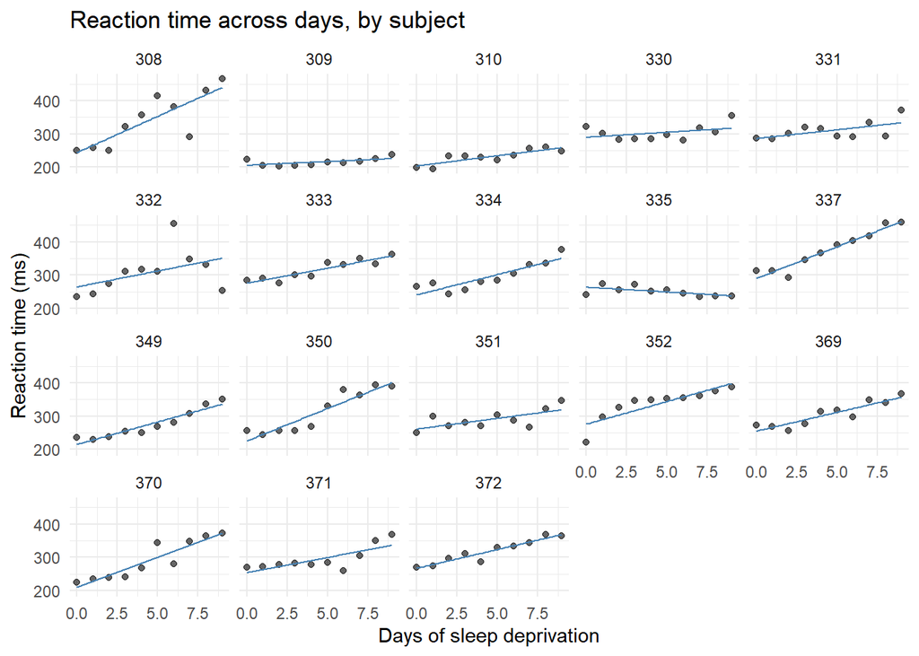

```r
library(ggplot2)
ggplot(sleepstudy, aes(x = Days, y = Reaction, group = Subject)) +
  geom_point(alpha = 0.6) +
  geom_smooth(method = "lm", se = FALSE, color = "steelblue", linewidth = 0.5) +
  facet_wrap(~ Subject) +
  labs(title = "Reaction time across days, by subject",
       x = "Days of sleep deprivation", y = "Reaction time (ms)") +
  theme_minimal()
```

Here $y_{ij}$ is the reaction time of subject $i$ on day $d_{ij}$, $\alpha_i$ and $\beta_i$ are the *subject-specific* intercept and slope, and $(\mu_\alpha, \mu_\beta)$ are the *population* (or *average*) intercept and slope. The variance components $\tau_\alpha^2$ and $\tau_\beta^2$ measure how much subjects differ from the population in baseline reaction time and in deterioration rate, while $\sigma^2$ captures the within-subject day-to-day residual noise. Following [Gelman (2006)](https://projecteuclid.org/journals/bayesian-analysis/volume-1/issue-3/Prior-distributions-for-variance-parameters-in-hierarchical-models-comment-on/10.1214/06-BA117A.full), we put weakly informative half-Cauchy priors on the standard deviations.

```r
# Data preparation -----------------------------------------------------------
# JAGS does not understand factors: convert Subject to an integer index.
sleepstudy$SubjID = as.integer(factor(sleepstudy$Subject))

Y       = sleepstudy$Reaction
Days    = sleepstudy$Days
Subject = sleepstudy$SubjID
N       = nrow(sleepstudy)
J       = length(unique(sleepstudy$SubjID))

dataList = list(Y = Y, Days = Days, Subject = Subject, N = N, J = J)

# JAGS model -----------------------------------------------------------------
model_string = textConnection("model {

  # Likelihood
  for (i in 1:N) {
    Y[i] ~ dnorm(alpha[Subject[i]] + beta[Subject[i]] * Days[i], inv.sigma2)
  }

  # Subject-level random effects
  for (j in 1:J) {
    alpha[j] ~ dnorm(mu_alpha, inv.tau2.alpha)
    beta[j]  ~ dnorm(mu_beta,  inv.tau2.beta)
  }

  # Population-level priors
  mu_alpha ~ dnorm(0, 1.0E-4)
  mu_beta  ~ dnorm(0, 1.0E-4)

  # Half-Cauchy(0, 5) on the standard deviations: dt(0, 1/scale^2, 1) T(0, )
  sigma     ~ dt(0, 0.04, 1) T(0, )
  tau_alpha ~ dt(0, 0.04, 1) T(0, )
  tau_beta  ~ dt(0, 0.04, 1) T(0, )

  inv.sigma2     = 1 / (sigma     * sigma)
  inv.tau2.alpha = 1 / (tau_alpha * tau_alpha)
  inv.tau2.beta  = 1 / (tau_beta  * tau_beta)
}")
```

```r
# Fit ------------------------------------------------------------------------
burn     = 5000
n.iter   = 20000
thin     = 5
n.chains = 4
n.adapt  = 1000

model = jags.model(model_string, data = dataList,
                   n.chains = n.chains, n.adapt = n.adapt)
update(model, n.iter = burn)

samples = coda.samples(model,
                       variable.names = c("mu_alpha", "mu_beta",
                                          "sigma", "tau_alpha", "tau_beta",
                                          "alpha", "beta"),
                       n.iter = n.iter, thin = thin)
```

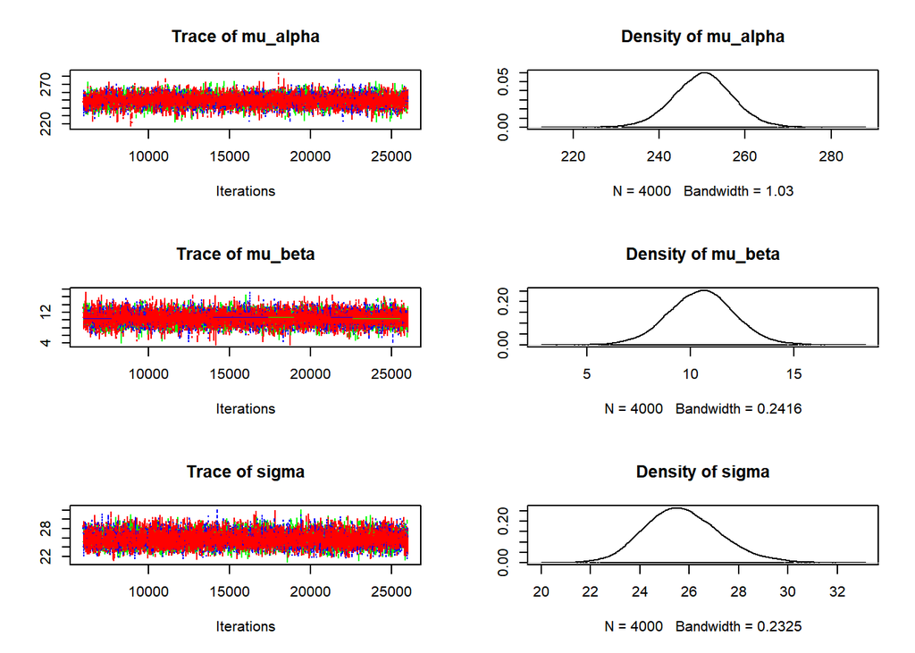

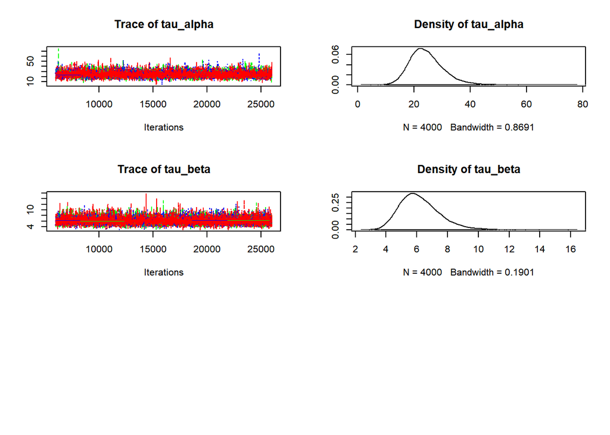

```r
# Diagnostics for the population parameters and variance components ----------
plot(samples[, c("mu_alpha", "mu_beta", "sigma", "tau_alpha", "tau_beta")])
```

```r
effectiveSize(samples[, c("mu_alpha", "mu_beta", "sigma", "tau_alpha", "tau_beta")])
```

```
##  mu_alpha   mu_beta     sigma tau_alpha  tau_beta
## 12588.375 14271.293 14527.524  8986.929 12422.145
```

```r
gelman.diag(samples[, c("mu_alpha", "mu_beta", "sigma", "tau_alpha", "tau_beta")])
```

```
## Potential scale reduction factors:
##
##           Point est. Upper C.I.
## mu_alpha           1          1
## mu_beta            1          1
## sigma              1          1
## tau_alpha          1          1
## tau_beta           1          1
##
## Multivariate psrf
##
## 1
```

```r
# Posterior summary
summary(samples[, c("mu_alpha", "mu_beta", "sigma", "tau_alpha", "tau_beta")])
```

```
##
## Iterations = 6005:26000
## Thinning interval = 5
## Number of chains = 4
## Sample size per chain = 4000
##
## 1. Empirical mean and standard deviation for each variable,
##    plus standard error of the mean:
##
##              Mean    SD Naive SE Time-series SE
## mu_alpha  250.122 6.952  0.05496        0.06206
## mu_beta    10.526 1.622  0.01282        0.01358
## sigma      25.735 1.520  0.01202        0.01262
## tau_alpha  24.513 5.995  0.04739        0.06329
## tau_beta    6.192 1.296  0.01025        0.01164
##
## 2. Quantiles for each variable:
##
##              2.5%     25%     50%     75%   97.5%
## mu_alpha  236.208 245.633 250.181 254.658 263.705
## mu_beta     7.292   9.462  10.539  11.580  13.716
## sigma      22.998  24.675  25.649  26.719  28.986
## tau_alpha  14.603  20.354  23.834  27.970  38.137
## tau_beta    4.086   5.279   6.033   6.945   9.148
```

The posterior of $\mu_\beta$ is concentrated around 10–11 ms/day: on average, each additional day of sleep restriction adds about 10 ms to the reaction time. The variance components tell a more interesting story: $\tau_\beta$ (around 6 ms/day) is sizeable compared to $\mu_\beta$, meaning subjects differ substantially in how badly sleep deprivation affects them. By contrast, $\sigma$ (within-subject residual sd) is the largest source of variability, indicating that even within a subject the day-to-day reaction times wobble a lot around the linear trend.

## Partial pooling: the heart of hierarchical modelling

To see partial pooling in action we compare three estimators of each subject’s slope $\beta_i$:

- **Complete pooling**: ignore the subject structure and fit one global slope $\hat{\beta}_{\text{pool}}$ via OLS on the full dataset.
- **No pooling**: fit a separate OLS regression per subject, getting 18 independent estimates $\hat{\beta}_i^{\text{OLS}}$.
- **Partial pooling** (our hierarchical model): the posterior mean of $\beta_i$ from JAGS.

Hierarchical estimates lie *between* the no-pooling and complete-pooling extremes; subjects with little signal (or few observations) are pulled more strongly towards the population mean.

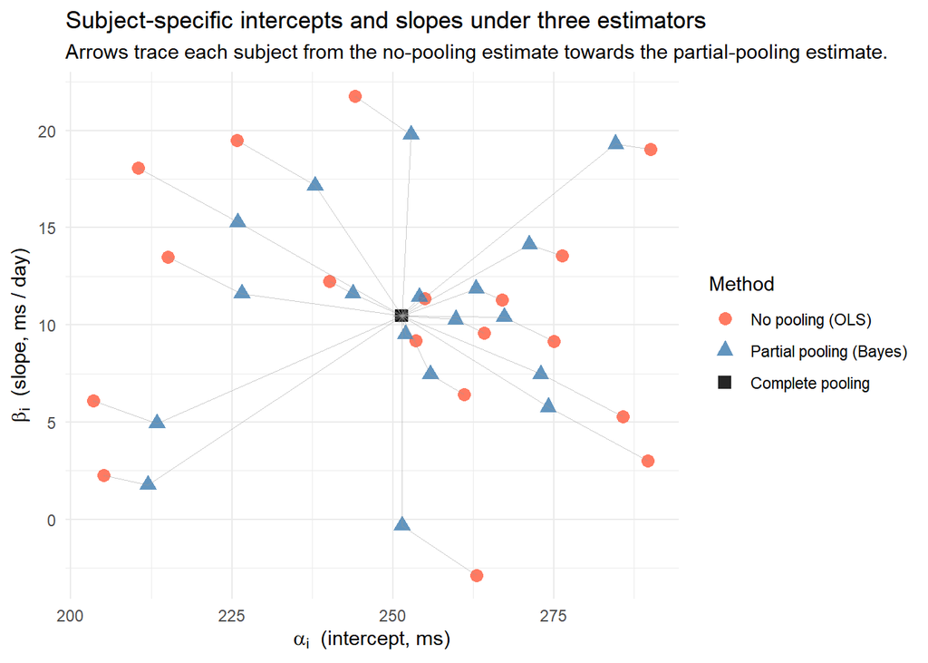

```r
# Complete pooling: one global slope
fit_pool   = lm(Reaction ~ Days, data = sleepstudy)
beta_pool  = coef(fit_pool)["Days"]
alpha_pool = coef(fit_pool)["(Intercept)"]

# No pooling: a separate fit per subject
nopool = sapply(split(sleepstudy, sleepstudy$Subject), function(d) {
  fit = lm(Reaction ~ Days, data = d)
  c(alpha = coef(fit)[1], beta = coef(fit)[2])
})
alpha_nopool = nopool["alpha.(Intercept)", ]
beta_nopool  = nopool["beta.Days", ]

# Partial pooling: posterior means from JAGS
samp_mat   = as.matrix(samples)
alpha_post = colMeans(samp_mat[, grep("^alpha\\[", colnames(samp_mat))])
beta_post  = colMeans(samp_mat[, grep("^beta\\[",  colnames(samp_mat))])

# Tidy data frame for plotting
shrink_df = data.frame(
  Subject = rep(seq_len(J), 3),
  alpha   = c(alpha_nopool, alpha_post, rep(alpha_pool, J)),
  beta    = c(beta_nopool,  beta_post,  rep(beta_pool,  J)),
  Method  = factor(rep(c("No pooling (OLS)", "Partial pooling (Bayes)",
                         "Complete pooling"), each = J),
                   levels = c("No pooling (OLS)", "Partial pooling (Bayes)",
                              "Complete pooling"))
)

ggplot(shrink_df, aes(x = alpha, y = beta, colour = Method, shape = Method)) +
  geom_point(size = 3, alpha = 0.85) +
  geom_path(aes(group = Subject), arrow = grid::arrow(length = unit(0.15, "cm")),
            colour = "grey60", alpha = 0.5, linewidth = 0.3) +
  scale_colour_manual(values = c("No pooling (OLS)"        = "tomato",
                                 "Partial pooling (Bayes)" = "steelblue",
                                 "Complete pooling"        = "black")) +
  labs(title = "Subject-specific intercepts and slopes under three estimators",
       subtitle = "Arrows trace each subject from the no-pooling estimate towards the partial-pooling estimate.",
       x = expression(alpha[i] * "  (intercept, ms)"),
       y = expression(beta[i] * "  (slope, ms / day)")) +
  theme_minimal()
```

The arrows make the shrinkage visible: each subject’s no-pooling estimate is pulled towards the centre of the cloud, and outlying subjects are pulled more strongly than typical ones — exactly the behaviour partial pooling promises.

## Posterior predictive: a brand-new subject

A nice consequence of the hierarchical specification is that the model knows what a *new, unseen* subject would look like: their parameters are draws from the population distribution learned from the existing 18 subjects. Concretely, the posterior predictive of the reaction time for a new subject on day $d^\star$ is obtained by sampling

$$\alpha^\star \sim \mathscr{N}(\mu_\alpha, \tau_\alpha^2), \qquad
\beta^\star \sim \mathscr{N}(\mu_\beta, \tau_\beta^2), \qquad
y^\star \sim \mathscr{N}(\alpha^\star + \beta^\star\, d^\star,
\sigma^2),$$

at every MCMC iteration, propagating the uncertainty in $(\mu_\alpha, \mu_\beta, \tau_\alpha, \tau_\beta, \sigma)$ into the prediction.

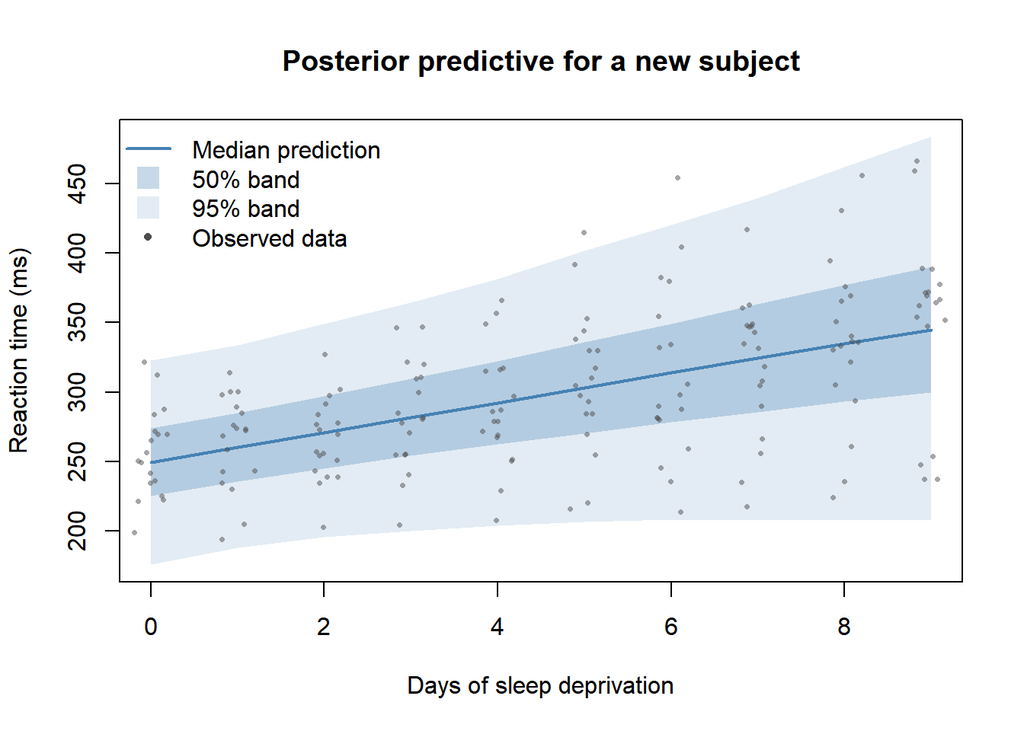

```r
# Posterior predictive trajectory for a new subject across days 0..9
mu_alpha_s  = samp_mat[, "mu_alpha"]
mu_beta_s   = samp_mat[, "mu_beta"]
tau_alpha_s = samp_mat[, "tau_alpha"]
tau_beta_s  = samp_mat[, "tau_beta"]
sigma_s     = samp_mat[, "sigma"]
S = nrow(samp_mat)

# At each MCMC draw, simulate the new subject's parameters once
alpha_star = rnorm(S, mu_alpha_s, tau_alpha_s)
beta_star  = rnorm(S, mu_beta_s,  tau_beta_s)

day_grid = 0:9
y_star_mat = sapply(day_grid, function(d) {
  rnorm(S, alpha_star + beta_star * d, sigma_s)
})

# Posterior predictive bands
band = apply(y_star_mat, 2, quantile, probs = c(0.025, 0.25, 0.5, 0.75, 0.975))

plot(day_grid, band["50%", ], type = "l", lwd = 2, col = "steelblue",
     ylim = range(band, sleepstudy$Reaction),
     xlab = "Days of sleep deprivation",
     ylab = "Reaction time (ms)",
     main = "Posterior predictive for a new subject")
polygon(c(day_grid, rev(day_grid)),
        c(band["2.5%",  ], rev(band["97.5%", ])),
        col = adjustcolor("steelblue", alpha.f = 0.15), border = NA)
polygon(c(day_grid, rev(day_grid)),
        c(band["25%",   ], rev(band["75%",   ])),
        col = adjustcolor("steelblue", alpha.f = 0.30), border = NA)
points(jitter(sleepstudy$Days), sleepstudy$Reaction, pch = 16, cex = 0.5,
       col = adjustcolor("grey30", alpha.f = 0.5))
legend("topleft",
       legend = c("Median prediction", "50% band", "95% band", "Observed data"),
       col    = c("steelblue", adjustcolor("steelblue", alpha.f = 0.30),
                  adjustcolor("steelblue", alpha.f = 0.15), "grey30"),
       lty    = c(1, NA, NA, NA), lwd = c(2, NA, NA, NA),
       pch    = c(NA, 15, 15, 16),
       pt.cex = c(NA, 2, 2, 0.7),
       bty    = "n")
```